# NSEPy=Part-1 and 2

```python
#import packages
import pandas as pd
from pandas import datetime
import numpy as np


#to plot within notebook
import matplotlib
import matplotlib.pyplot as plt
%matplotlib inline
plt.style.use('fivethirtyeight')
# Above is a special style template for matplotlib, highly useful for visualizing time series data

import seaborn as sns


#setting figure size
from matplotlib.pylab import rcParams
rcParams['figure.figsize'] = 10,10
```

```python
path = 'E:/GitHub_Project_upload/done/python-test/'

TCS = pd.read_csv(path + 'tcs_stock.csv', parse_dates=['Date'])

INFY = pd.read_csv(path + 'infy_stock.csv', parse_dates=['Date'])

NIFTY = pd.read_csv(path + 'nifty_it_index.csv', parse_dates=['Date'])


stocks = [TCS, INFY, NIFTY]


TCS.name = 'TCS'
INFY.name = 'INFY'
NIFTY.name = 'NIFTY_IT'
```

```python
TCS["Date"] = pd.to_datetime(TCS["Date"])
INFY["Date"] = pd.to_datetime(INFY["Date"])
NIFTY["Date"] = pd.to_datetime(NIFTY["Date"])
```

```python
TCS.head(10)
```

|  | Date | Symbol | Series | Prev Close | Open | High | Low | Last | Close | VWAP | Volume | Turnover | Trades | Deliverable Volume | %Deliverble |
| --- | --- | --- | --- | --- | --- | --- | --- | --- | --- | --- | --- | --- | --- | --- | --- |
| 0 | 2015-01-01 | TCS | EQ | 2558.25 | 2567.0 | 2567.00 | 2541.00 | 2550.00 | 2545.55 | 2548.51 | 183415 | 4.674345e+13 | 8002 | 52870 | 0.2883 |
| 1 | 2015-01-02 | TCS | EQ | 2545.55 | 2551.0 | 2590.95 | 2550.60 | 2588.40 | 2579.45 | 2568.19 | 462870 | 1.188740e+14 | 27585 | 309350 | 0.6683 |
| 2 | 2015-01-05 | TCS | EQ | 2579.45 | 2581.0 | 2599.90 | 2524.65 | 2538.10 | 2540.25 | 2563.94 | 877121 | 2.248886e+14 | 43234 | 456728 | 0.5207 |
| 3 | 2015-01-06 | TCS | EQ | 2540.25 | 2529.1 | 2529.10 | 2440.00 | 2450.05 | 2446.60 | 2466.90 | 1211892 | 2.989615e+14 | 84503 | 714306 | 0.5894 |
| 4 | 2015-01-07 | TCS | EQ | 2446.60 | 2470.0 | 2479.15 | 2407.45 | 2426.90 | 2417.70 | 2433.96 | 1318166 | 3.208362e+14 | 101741 | 886368 | 0.6724 |
| 5 | 2015-01-08 | TCS | EQ | 2417.70 | 2442.4 | 2449.00 | 2420.55 | 2446.00 | 2443.80 | 2434.81 | 782704 | 1.905739e+14 | 47699 | 450768 | 0.5759 |
| 6 | 2015-01-09 | TCS | EQ | 2443.80 | 2455.0 | 2519.90 | 2450.00 | 2510.00 | 2512.30 | 2490.01 | 1598821 | 3.981082e+14 | 81743 | 865777 | 0.5415 |
| 7 | 2015-01-12 | TCS | EQ | 2512.30 | 2517.0 | 2528.00 | 2480.25 | 2527.95 | 2509.70 | 2497.82 | 798003 | 1.993266e+14 | 58810 | 451228 | 0.5654 |
| 8 | 2015-01-13 | TCS | EQ | 2509.70 | 2520.0 | 2530.40 | 2480.10 | 2498.00 | 2497.90 | 2509.40 | 734216 | 1.842440e+14 | 49993 | 386133 | 0.5259 |
| 9 | 2015-01-14 | TCS | EQ | 2497.90 | 2516.0 | 2531.80 | 2500.50 | 2525.05 | 2521.95 | 2517.54 | 893548 | 2.249546e+14 | 69237 | 498193 | 0.5575 |

```python
TCS.shape
```

```
(248, 15)
```

```python
INFY.head(10)
```

|  | Date | Symbol | Series | Prev Close | Open | High | Low | Last | Close | VWAP | Volume | Turnover | Trades | Deliverable Volume | %Deliverble |
| --- | --- | --- | --- | --- | --- | --- | --- | --- | --- | --- | --- | --- | --- | --- | --- |
| 0 | 2015-01-01 | INFY | EQ | 1972.55 | 1968.95 | 1982.00 | 1956.90 | 1971.00 | 1974.40 | 1971.34 | 500691 | 9.870306e+13 | 14908 | 258080 | 0.5154 |
| 1 | 2015-01-02 | INFY | EQ | 1974.40 | 1972.00 | 2019.05 | 1972.00 | 2017.95 | 2013.20 | 2003.25 | 1694580 | 3.394669e+14 | 54166 | 1249104 | 0.7371 |
| 2 | 2015-01-05 | INFY | EQ | 2013.20 | 2009.90 | 2030.00 | 1977.50 | 1996.00 | 1995.90 | 2004.59 | 2484256 | 4.979911e+14 | 82694 | 1830962 | 0.7370 |
| 3 | 2015-01-06 | INFY | EQ | 1995.90 | 1980.00 | 1985.00 | 1934.10 | 1965.10 | 1954.20 | 1954.82 | 2416829 | 4.724458e+14 | 108209 | 1772070 | 0.7332 |
| 4 | 2015-01-07 | INFY | EQ | 1954.20 | 1965.00 | 1974.75 | 1950.00 | 1966.05 | 1963.55 | 1962.59 | 1812479 | 3.557162e+14 | 62463 | 1317720 | 0.7270 |
| 5 | 2015-01-08 | INFY | EQ | 1963.55 | 1985.60 | 1997.00 | 1950.00 | 1979.25 | 1973.45 | 1972.78 | 3391230 | 6.690160e+14 | 92752 | 2686012 | 0.7920 |
| 6 | 2015-01-09 | INFY | EQ | 1973.45 | 1980.10 | 2109.00 | 1913.05 | 2075.30 | 2074.45 | 2037.69 | 11215832 | 2.285439e+15 | 359214 | 3369489 | 0.3004 |
| 7 | 2015-01-12 | INFY | EQ | 2074.45 | 2092.00 | 2119.20 | 2075.00 | 2112.95 | 2115.95 | 2099.40 | 3189722 | 6.696516e+14 | 107209 | 1818800 | 0.5702 |
| 8 | 2015-01-13 | INFY | EQ | 2115.95 | 2107.80 | 2107.80 | 2075.00 | 2092.00 | 2088.90 | 2089.42 | 2200309 | 4.597374e+14 | 66676 | 1385009 | 0.6295 |
| 9 | 2015-01-14 | INFY | EQ | 2088.90 | 2098.50 | 2133.00 | 2092.60 | 2129.00 | 2128.65 | 2110.88 | 2480315 | 5.235638e+14 | 53263 | 1832958 | 0.7390 |

```python
NIFTY.head(10)
```

|  | Date | Open | High | Low | Close | Volume | Turnover |
| --- | --- | --- | --- | --- | --- | --- | --- |
| 0 | 2015-01-01 | 11214.80 | 11235.75 | 11166.35 | 11215.70 | 4246150 | 3.575100e+09 |
| 1 | 2015-01-02 | 11214.65 | 11399.10 | 11214.65 | 11372.10 | 10004862 | 9.645600e+09 |
| 2 | 2015-01-05 | 11369.35 | 11433.75 | 11186.95 | 11248.55 | 8858018 | 1.059000e+10 |
| 3 | 2015-01-06 | 11186.10 | 11186.10 | 10909.00 | 10959.90 | 12515739 | 1.364500e+10 |
| 4 | 2015-01-07 | 11013.20 | 11042.35 | 10889.55 | 10916.00 | 10976356 | 1.203440e+10 |
| 5 | 2015-01-08 | 11031.15 | 11058.15 | 10915.05 | 11018.15 | 12975117 | 1.485630e+10 |
| 6 | 2015-01-09 | 11058.05 | 11484.90 | 10932.20 | 11399.65 | 24812224 | 3.536420e+10 |
| 7 | 2015-01-12 | 11456.00 | 11565.85 | 11378.80 | 11543.65 | 16505074 | 1.712310e+10 |
| 8 | 2015-01-13 | 11545.25 | 11546.60 | 11437.95 | 11502.80 | 12511358 | 1.417510e+10 |
| 9 | 2015-01-14 | 11561.95 | 11631.55 | 11521.00 | 11614.30 | 12544558 | 1.438530e+10 |

```python
# data extraction


def features_build(df):
    df['Date'] = pd.to_datetime(df['Date'])
    df['Year'] = df['Date'].dt.year
    df['Month'] = df.Date.dt.month
    df['Day'] = df.Date.dt.day
    df['WeekOfYear'] = df.Date.dt.weekofyear



for i in range(len(stocks)):
    # print(stocks[i])
    features_build(stocks[i])
```

```python
# check for newly added features.
TCS.shape
```

```
(248, 19)
```

```python
TCS.head()
```

|  | Date | Symbol | Series | Prev Close | Open | High | Low | Last | Close | VWAP | Volume | Turnover | Trades | Deliverable Volume | %Deliverble | Year | Month | Day | WeekOfYear |
| --- | --- | --- | --- | --- | --- | --- | --- | --- | --- | --- | --- | --- | --- | --- | --- | --- | --- | --- | --- |
| 0 | 2015-01-01 | TCS | EQ | 2558.25 | 2567.0 | 2567.00 | 2541.00 | 2550.00 | 2545.55 | 2548.51 | 183415 | 4.674345e+13 | 8002 | 52870 | 0.2883 | 2015 | 1 | 1 | 1 |
| 1 | 2015-01-02 | TCS | EQ | 2545.55 | 2551.0 | 2590.95 | 2550.60 | 2588.40 | 2579.45 | 2568.19 | 462870 | 1.188740e+14 | 27585 | 309350 | 0.6683 | 2015 | 1 | 2 | 1 |
| 2 | 2015-01-05 | TCS | EQ | 2579.45 | 2581.0 | 2599.90 | 2524.65 | 2538.10 | 2540.25 | 2563.94 | 877121 | 2.248886e+14 | 43234 | 456728 | 0.5207 | 2015 | 1 | 5 | 2 |
| 3 | 2015-01-06 | TCS | EQ | 2540.25 | 2529.1 | 2529.10 | 2440.00 | 2450.05 | 2446.60 | 2466.90 | 1211892 | 2.989615e+14 | 84503 | 714306 | 0.5894 | 2015 | 1 | 6 | 2 |
| 4 | 2015-01-07 | TCS | EQ | 2446.60 | 2470.0 | 2479.15 | 2407.45 | 2426.90 | 2417.70 | 2433.96 | 1318166 | 3.208362e+14 | 101741 | 886368 | 0.6724 | 2015 | 1 | 7 | 2 |

**Let us select Close (Closing Price to be the target variable).**

# PART-1

```python
# Lets define a function for moving average with rolling window

# Sklearn has seperate function to calculate this: [ DataFrame.rolling(window).mean() ].

def moving_average(series, n):
    """
        Calculate average of last n observations

        n - rolling window
    """
    return np.average(series[-n:])


'''
# We can also imlement this user-defined function. But, first we need to isolate both 'Date' and 'Close' columns
under consideration. After that, we need to resample according to week , using:

df.resample('W')

function. Then We will pass the 'Close' column as the 'series' argument to the custom built function.
And, n = rolling window size.


But: We are not doing that here to maintain simplicity in code.

'''
```

[output not shown]

Let us calculate moving averages (closing price) for weeks = [4,16,28,40,52].

```python
weeks = [4, 16, 28, 40, 52]
```

```python
def indexing(stock):
    stock.index = stock['Date']
    return stock
```

```python
indexing(TCS)
indexing(INFY)
indexing(NIFTY)
```

| Date | Date | Open | High | Low | Close | Volume | Turnover | Year | Month | Day | WeekOfYear |
| --- | --- | --- | --- | --- | --- | --- | --- | --- | --- | --- | --- |
| 2015-01-01 | 2015-01-01 | 11214.80 | 11235.75 | 11166.35 | 11215.70 | 4246150 | 3.575100e+09 | 2015 | 1 | 1 | 1 |
| 2015-01-02 | 2015-01-02 | 11214.65 | 11399.10 | 11214.65 | 11372.10 | 10004862 | 9.645600e+09 | 2015 | 1 | 2 | 1 |
| 2015-01-05 | 2015-01-05 | 11369.35 | 11433.75 | 11186.95 | 11248.55 | 8858018 | 1.059000e+10 | 2015 | 1 | 5 | 2 |
| 2015-01-06 | 2015-01-06 | 11186.10 | 11186.10 | 10909.00 | 10959.90 | 12515739 | 1.364500e+10 | 2015 | 1 | 6 | 2 |
| 2015-01-07 | 2015-01-07 | 11013.20 | 11042.35 | 10889.55 | 10916.00 | 10976356 | 1.203440e+10 | 2015 | 1 | 7 | 2 |
| 2015-01-08 | 2015-01-08 | 11031.15 | 11058.15 | 10915.05 | 11018.15 | 12975117 | 1.485630e+10 | 2015 | 1 | 8 | 2 |
| 2015-01-09 | 2015-01-09 | 11058.05 | 11484.90 | 10932.20 | 11399.65 | 24812224 | 3.536420e+10 | 2015 | 1 | 9 | 2 |
| 2015-01-12 | 2015-01-12 | 11456.00 | 11565.85 | 11378.80 | 11543.65 | 16505074 | 1.712310e+10 | 2015 | 1 | 12 | 3 |
| 2015-01-13 | 2015-01-13 | 11545.25 | 11546.60 | 11437.95 | 11502.80 | 12511358 | 1.417510e+10 | 2015 | 1 | 13 | 3 |
| 2015-01-14 | 2015-01-14 | 11561.95 | 11631.55 | 11521.00 | 11614.30 | 12544558 | 1.438530e+10 | 2015 | 1 | 14 | 3 |
| 2015-01-15 | 2015-01-15 | 11672.30 | 11774.50 | 11575.10 | 11669.85 | 13882213 | 1.764560e+10 | 2015 | 1 | 15 | 3 |
| 2015-01-16 | 2015-01-16 | 11708.85 | 11708.85 | 11582.85 | 11659.60 | 12368107 | 1.714690e+10 | 2015 | 1 | 16 | 3 |
| 2015-01-19 | 2015-01-19 | 11732.50 | 11797.60 | 11629.05 | 11642.75 | 13696381 | 1.183750e+10 | 2015 | 1 | 19 | 4 |
| 2015-01-20 | 2015-01-20 | 11681.80 | 11721.90 | 11635.70 | 11695.00 | 11021415 | 1.234730e+10 | 2015 | 1 | 20 | 4 |
| 2015-01-21 | 2015-01-21 | 11732.45 | 11838.30 | 11659.70 | 11813.70 | 18679282 | 1.973070e+10 | 2015 | 1 | 21 | 4 |
| 2015-01-22 | 2015-01-22 | 11832.55 | 11884.50 | 11782.95 | 11850.85 | 15715515 | 1.655670e+10 | 2015 | 1 | 22 | 4 |
| 2015-01-23 | 2015-01-23 | 11877.90 | 11921.00 | 11767.40 | 11885.15 | 30034833 | 2.001210e+10 | 2015 | 1 | 23 | 4 |
| 2015-01-27 | 2015-01-27 | 11915.60 | 11917.25 | 11679.55 | 11693.45 | 17005337 | 1.866840e+10 | 2015 | 1 | 27 | 5 |
| 2015-01-28 | 2015-01-28 | 11712.55 | 11821.80 | 11693.80 | 11809.55 | 16876897 | 1.937590e+10 | 2015 | 1 | 28 | 5 |
| 2015-01-29 | 2015-01-29 | 11812.35 | 11861.50 | 11728.75 | 11824.15 | 15520902 | 2.160790e+10 | 2015 | 1 | 29 | 5 |
| 2015-01-30 | 2015-01-30 | 11998.35 | 12003.35 | 11799.35 | 11824.75 | 18559078 | 2.905950e+10 | 2015 | 1 | 30 | 5 |
| 2015-02-02 | 2015-02-02 | 11871.35 | 11972.60 | 11847.80 | 11943.95 | 17272113 | 2.304050e+10 | 2015 | 2 | 2 | 6 |
| 2015-02-03 | 2015-02-03 | 11963.75 | 12000.65 | 11849.00 | 11963.90 | 21053605 | 1.770590e+10 | 2015 | 2 | 3 | 6 |
| 2015-02-04 | 2015-02-04 | 12027.10 | 12027.10 | 11902.35 | 11938.90 | 14453955 | 1.290570e+10 | 2015 | 2 | 4 | 6 |
| 2015-02-05 | 2015-02-05 | 11967.75 | 12295.35 | 11963.80 | 12165.15 | 15826989 | 2.124010e+10 | 2015 | 2 | 5 | 6 |
| 2015-02-06 | 2015-02-06 | 12190.70 | 12380.45 | 12186.95 | 12267.95 | 11167848 | 1.325990e+10 | 2015 | 2 | 6 | 6 |
| 2015-02-09 | 2015-02-09 | 12160.90 | 12285.45 | 12160.90 | 12249.30 | 10996415 | 1.221010e+10 | 2015 | 2 | 9 | 7 |
| 2015-02-10 | 2015-02-10 | 12215.20 | 12297.75 | 12129.65 | 12162.85 | 17687306 | 1.851870e+10 | 2015 | 2 | 10 | 7 |
| 2015-02-11 | 2015-02-11 | 12198.45 | 12265.70 | 12149.35 | 12243.40 | 12905131 | 1.363700e+10 | 2015 | 2 | 11 | 7 |
| 2015-02-12 | 2015-02-12 | 12277.20 | 12397.00 | 12253.05 | 12372.00 | 16012381 | 1.515950e+10 | 2015 | 2 | 12 | 7 |
| ... | ... | ... | ... | ... | ... | ... | ... | ... | ... | ... | ... |
| 2015-11-18 | 2015-11-18 | 10967.75 | 10969.50 | 10799.00 | 10836.70 | 10167296 | 1.012920e+10 | 2015 | 11 | 18 | 47 |
| 2015-11-19 | 2015-11-19 | 10910.50 | 11059.85 | 10893.75 | 11032.90 | 9850813 | 1.008630e+10 | 2015 | 11 | 19 | 47 |
| 2015-11-20 | 2015-11-20 | 11045.65 | 11195.75 | 11036.90 | 11118.85 | 10781657 | 1.071380e+10 | 2015 | 11 | 20 | 47 |
| 2015-11-23 | 2015-11-23 | 11126.25 | 11189.50 | 11084.35 | 11121.20 | 8727231 | 8.513000e+09 | 2015 | 11 | 23 | 48 |
| 2015-11-24 | 2015-11-24 | 11096.40 | 11122.05 | 11036.05 | 11057.35 | 7784549 | 7.501700e+09 | 2015 | 11 | 24 | 48 |
| 2015-11-26 | 2015-11-26 | 11048.40 | 11129.25 | 11013.90 | 11042.95 | 15045631 | 1.492540e+10 | 2015 | 11 | 26 | 48 |
| 2015-11-27 | 2015-11-27 | 11064.60 | 11136.40 | 11031.45 | 11122.90 | 7402279 | 7.693000e+09 | 2015 | 11 | 27 | 48 |
| 2015-11-30 | 2015-11-30 | 11147.85 | 11279.65 | 11083.60 | 11206.00 | 21067524 | 2.154870e+10 | 2015 | 11 | 30 | 49 |
| 2015-12-01 | 2015-12-01 | 11216.95 | 11293.20 | 11216.95 | 11256.30 | 9112940 | 9.271000e+09 | 2015 | 12 | 1 | 49 |
| 2015-12-02 | 2015-12-02 | 11298.90 | 11298.90 | 11134.90 | 11149.60 | 7524996 | 8.086300e+09 | 2015 | 12 | 2 | 49 |
| 2015-12-03 | 2015-12-03 | 11149.30 | 11153.70 | 11067.55 | 11081.90 | 9384540 | 9.792900e+09 | 2015 | 12 | 3 | 49 |
| 2015-12-04 | 2015-12-04 | 11034.65 | 11037.95 | 10940.30 | 10969.05 | 10062731 | 9.755500e+09 | 2015 | 12 | 4 | 49 |
| 2015-12-07 | 2015-12-07 | 11009.50 | 11054.00 | 10943.85 | 10998.65 | 8477753 | 8.108600e+09 | 2015 | 12 | 7 | 50 |
| 2015-12-08 | 2015-12-08 | 10989.20 | 11109.30 | 10946.00 | 10981.85 | 8486760 | 8.256700e+09 | 2015 | 12 | 8 | 50 |
| 2015-12-09 | 2015-12-09 | 10978.25 | 11027.30 | 10916.25 | 10930.05 | 11006038 | 1.352400e+10 | 2015 | 12 | 9 | 50 |
| 2015-12-10 | 2015-12-10 | 10971.55 | 11073.15 | 10931.15 | 11055.50 | 7908231 | 8.326600e+09 | 2015 | 12 | 10 | 50 |
| 2015-12-11 | 2015-12-11 | 11086.55 | 11086.55 | 11015.60 | 11043.05 | 8502528 | 9.019600e+09 | 2015 | 12 | 11 | 50 |
| 2015-12-14 | 2015-12-14 | 10940.75 | 11124.90 | 10940.75 | 11099.70 | 7044052 | 8.280500e+09 | 2015 | 12 | 14 | 51 |
| 2015-12-15 | 2015-12-15 | 11139.55 | 11139.55 | 11044.35 | 11058.25 | 9065922 | 8.154000e+09 | 2015 | 12 | 15 | 51 |
| 2015-12-16 | 2015-12-16 | 11081.75 | 11187.85 | 11081.75 | 11144.90 | 8751937 | 8.490500e+09 | 2015 | 12 | 16 | 51 |
| 2015-12-17 | 2015-12-17 | 11182.95 | 11293.05 | 11122.45 | 11275.15 | 9556916 | 9.097200e+09 | 2015 | 12 | 17 | 51 |
| 2015-12-18 | 2015-12-18 | 11227.15 | 11227.15 | 11094.80 | 11122.50 | 11781399 | 1.222450e+10 | 2015 | 12 | 18 | 51 |
| 2015-12-21 | 2015-12-21 | 11096.40 | 11232.50 | 11067.20 | 11224.75 | 6043899 | 6.415600e+09 | 2015 | 12 | 21 | 52 |
| 2015-12-22 | 2015-12-22 | 11201.80 | 11201.80 | 11081.15 | 11095.45 | 5998230 | 6.366300e+09 | 2015 | 12 | 22 | 52 |
| 2015-12-23 | 2015-12-23 | 11163.80 | 11206.40 | 11130.65 | 11195.65 | 4638075 | 4.562900e+09 | 2015 | 12 | 23 | 52 |
| 2015-12-24 | 2015-12-24 | 11193.25 | 11197.50 | 11152.85 | 11184.90 | 2927864 | 3.182700e+09 | 2015 | 12 | 24 | 52 |
| 2015-12-28 | 2015-12-28 | 11152.70 | 11303.05 | 11146.85 | 11271.80 | 8055590 | 1.001900e+10 | 2015 | 12 | 28 | 53 |
| 2015-12-29 | 2015-12-29 | 11257.05 | 11287.50 | 11206.60 | 11253.45 | 6024174 | 6.626200e+09 | 2015 | 12 | 29 | 53 |
| 2015-12-30 | 2015-12-30 | 11247.35 | 11263.60 | 11100.10 | 11117.60 | 6564991 | 7.071900e+09 | 2015 | 12 | 30 | 53 |
| 2015-12-31 | 2015-12-31 | 11113.00 | 11233.85 | 11113.00 | 11212.55 | 8197040 | 8.590500e+09 | 2015 | 12 | 31 | 53 |

248 rows × 11 columns

```python
def plot_time_series(stock, weeks = [4, 16, 28, 40, 52]):

    dummy = pd.DataFrame()
    # First Resampling into Weeks format to calculate for weeks
    dummy['Close'] = stock['Close'].resample('W').mean()

    for i in range(len(weeks)):
        m_a = dummy['Close'].rolling(weeks[i]).mean() # M.A using inbuilt function
        dummy[" Mov.AVG for " + str(weeks[i])+ " Weeks"] = m_a
        print('Calculated Moving Averages: for {0} weeks: \n\n {1}' .format(weeks[i], dummy['Close']))
    dummy.plot(title="Moving Averages for {} \n\n" .format(stock.name))
```

```
Calculated Moving Averages: for 4 weeks:

 Date
2015-01-04    2562.500000
2015-01-11    2472.130000
2015-01-18    2520.160000
2015-01-25    2508.480000
2015-02-01    2517.087500
2015-02-08    2542.980000
2015-02-15    2482.970000
2015-02-22    2644.262500
2015-03-01    2677.941667
2015-03-08    2721.962500
2015-03-15    2619.490000
2015-03-22    2582.510000
2015-03-29    2562.020000
2015-04-05    2553.583333
2015-04-12    2618.400000
2015-04-19    2585.225000
2015-04-26    2450.250000
2015-05-03    2486.550000
2015-05-10    2506.990000
2015-05-17    2520.940000
2015-05-24    2552.710000
2015-05-31    2608.980000
2015-06-07    2602.010000
2015-06-14    2563.390000
2015-06-21    2522.040000
2015-06-28    2575.840000
2015-07-05    2583.720000
2015-07-12    2568.300000
2015-07-19    2531.880000
2015-07-26    2532.470000
2015-08-02    2499.450000
2015-08-09    2538.200000
2015-08-16    2637.360000
2015-08-23    2704.450000
2015-08-30    2573.610000
2015-09-06    2569.260000
2015-09-13    2545.440000
```

[output cut: 230 more lines]

```
2015-10-04    2603.650000
2015-10-11    2665.810000
2015-10-18    2523.270000
2015-10-25    2520.662500
2015-11-01    2517.460000
2015-11-08    2516.600000
2015-11-15    2448.925000
2015-11-22    2375.500000
2015-11-29    2364.475000
2015-12-06    2354.190000
2015-12-13    2357.400000
2015-12-20    2403.850000
2015-12-27    2427.875000
2016-01-03    2443.412500
Freq: W-SUN, Name: Close, dtype: float64
```

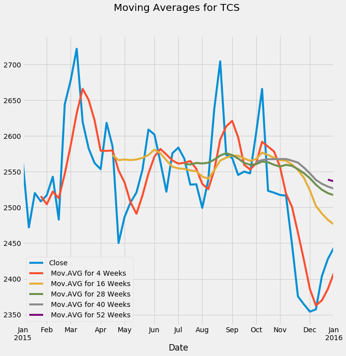

```python
plot_time_series(TCS)
```

```
Calculated Moving Averages: for 4 weeks:

 Date
2015-01-04    1993.800000
2015-01-11    1992.310000
2015-01-18    2117.210000
2015-01-25    2161.620000
2015-02-01    2142.112500
2015-02-08    2164.980000
2015-02-15    2283.870000
2015-02-22    2295.762500
2015-03-01    2279.383333
2015-03-08    2277.950000
2015-03-15    2201.790000
2015-03-22    2244.910000
2015-03-29    2202.500000
2015-04-05    2206.766667
2015-04-12    2197.440000
2015-04-19    2206.600000
2015-04-26    2105.930000
2015-05-03    1962.237500
2015-05-10    1955.970000
2015-05-17    1958.800000
2015-05-24    2031.520000
2015-05-31    2006.470000
2015-06-07    2023.410000
2015-06-14    1998.270000
2015-06-21     996.560000
2015-06-28    1003.010000
2015-07-05     990.040000
2015-07-12     959.360000
2015-07-19     979.260000
2015-07-26    1080.530000
2015-08-02    1072.120000
2015-08-09    1081.020000
2015-08-16    1129.360000
2015-08-23    1153.300000
2015-08-30    1087.230000
2015-09-06    1091.230000
2015-09-13    1075.490000
```

[output cut: 230 more lines]

```
2015-10-04    1140.600000
2015-10-11    1153.820000
2015-10-18    1102.430000
2015-10-25    1131.550000
2015-11-01    1147.050000
2015-11-08    1134.940000
2015-11-15    1111.712500
2015-11-22    1052.380000
2015-11-29    1053.400000
2015-12-06    1066.880000
2015-12-13    1043.800000
2015-12-20    1086.630000
2015-12-27    1096.100000
2016-01-03    1100.287500
Freq: W-SUN, Name: Close, dtype: float64
```

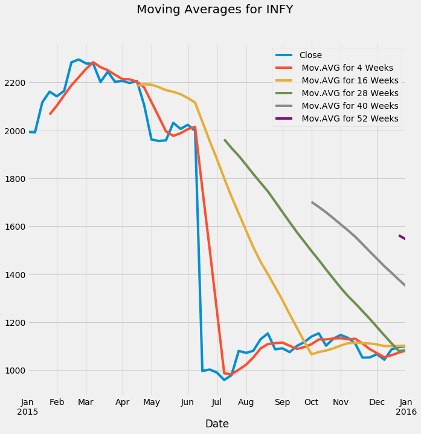

```python
plot_time_series(INFY)
```

```
Calculated Moving Averages: for 4 weeks:

 Date
2015-01-04    11293.9000
2015-01-11    11108.4500
2015-01-18    11598.0400
2015-01-25    11777.4900
2015-02-01    11787.9750
2015-02-08    12055.9700
2015-02-15    12298.5000
2015-02-22    12603.9250
2015-03-01    12567.3500
2015-03-08    12728.9250
2015-03-15    12383.0900
2015-03-22    12343.4000
2015-03-29    12104.1300
2015-04-05    12045.3500
2015-04-12    12149.4100
2015-04-19    12087.6000
2015-04-26    11439.2800
2015-05-03    11061.5750
2015-05-10    11120.0700
2015-05-17    11175.8000
2015-05-24    11514.0700
2015-05-31    11519.7300
2015-06-07    11381.0800
2015-06-14    11211.9500
2015-06-21    11163.1100
2015-06-28    11339.5300
2015-07-05    11154.1100
2015-07-12    11000.4400
2015-07-19    11130.7500
2015-07-26    11517.8000
2015-08-02    11425.6200
2015-08-09    11542.7000
2015-08-16    11859.2800
2015-08-23    12085.5600
2015-08-30    11420.2300
2015-09-06    11554.6600
2015-09-13    11408.5000
```

[output cut: 230 more lines]

```
2015-10-04    11901.2375
2015-10-11    11810.5400
2015-10-18    11438.4600
2015-10-25    11515.7000
2015-11-01    11567.6500
2015-11-08    11523.2300
2015-11-15    11244.6250
2015-11-22    11005.4700
2015-11-29    11086.1000
2015-12-06    11132.5700
2015-12-13    11001.8200
2015-12-20    11140.1000
2015-12-27    11175.1875
2016-01-03    11213.8500
Freq: W-SUN, Name: Close, dtype: float64
```

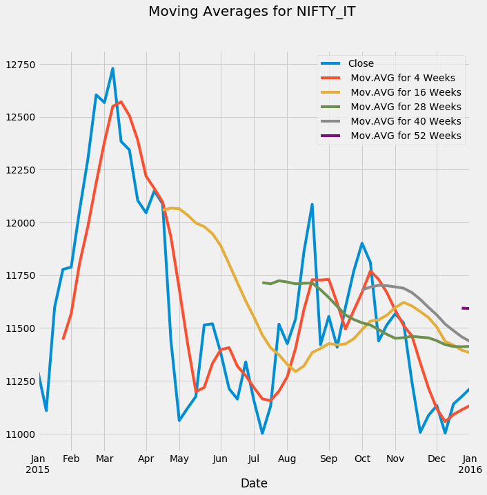

```python
plot_time_series(NIFTY)
```

**Now , we further have to put rolling window as 10 and then 75. Keeping in mind the stock market holidays. For that, we first need to resample again as per days. We are not worried about special/ national holidays. because for that we need to use special calendar APIs, which may provide us holidays for each year. Here, we are only considering *STOCK MARKET HOLIDAYS*. ie. Saturday and Sunday**

**Thus, instead of resample(), we will here use resample.Resampler.asfreq() function. Because it also provide us option of padding (backwardfill/forwardfill missing values "not NANs" ). source: https://pandas.pydata.org/pandas-docs/stable/generated/pandas.DataFrame.asfreq.html We are using this, because on saturdays and sundays, market remains closed, so friday's close price could be forwarded in closing days.**

```python
TCS = TCS.asfreq('D', method ='pad')        # pad-ffill : forward-fill
INFY = INFY.asfreq('D', method ='pad')
NIFTY = NIFTY.asfreq('D', method ='pad')


TCS.name = 'TCS'
INFY.name = 'INFY'
NIFTY.name = 'NIFTY_IT'
```

```python
def plot_roll_win(stock, win = [10, 75]):

    dummy = pd.DataFrame()

    dummy['Close'] = stock['Close']

    for i in range(len(win)):
        m_a = dummy['Close'].rolling(win[i]).mean() # M.A using predefined function
        dummy[" Mov.AVG for " + str(win[i])+ " Roll Window"] = m_a
        print('Calculated Moving Averages: for {0} weeks: \n\n {1}' .format(win[i], dummy['Close']))
    dummy.plot(title="Moving Averages for {} \n\n" .format(stock.name))
```

```
Calculated Moving Averages: for 10 weeks:

 Date
2015-01-01    2545.55
2015-01-02    2579.45
2015-01-03    2579.45
2015-01-04    2579.45
2015-01-05    2540.25
2015-01-06    2446.60
2015-01-07    2417.70
2015-01-08    2443.80
2015-01-09    2512.30
2015-01-10    2512.30
2015-01-11    2512.30
2015-01-12    2509.70
2015-01-13    2497.90
2015-01-14    2521.95
2015-01-15    2539.10
2015-01-16    2532.15
2015-01-17    2532.15
2015-01-18    2532.15
2015-01-19    2511.00
2015-01-20    2500.45
2015-01-21    2513.80
2015-01-22    2513.55
2015-01-23    2503.60
2015-01-24    2503.60
2015-01-25    2503.60
2015-01-26    2503.60
2015-01-27    2502.05
2015-01-28    2539.60
2015-01-29    2544.65
2015-01-30    2482.05
               ...
2015-12-02    2365.20
2015-12-03    2350.75
2015-12-04    2328.40
2015-12-05    2328.40
2015-12-06    2328.40
2015-12-07    2319.80
```

[output cut: 75 more lines]

```
2015-12-18    2416.80
2015-12-19    2416.80
2015-12-20    2416.80
2015-12-21    2446.40
2015-12-22    2405.05
2015-12-23    2425.80
2015-12-24    2434.25
2015-12-25    2434.25
2015-12-26    2434.25
2015-12-27    2434.25
2015-12-28    2462.70
2015-12-29    2455.80
2015-12-30    2418.30
2015-12-31    2436.85
Freq: D, Name: Close, dtype: float64
```

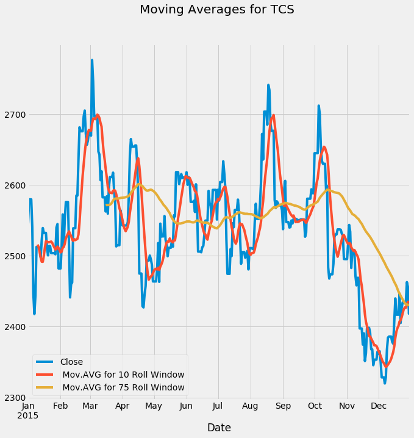

```python
plot_roll_win(TCS)
```

```
Calculated Moving Averages: for 10 weeks:

 Date
2015-01-01    1974.40
2015-01-02    2013.20
2015-01-03    2013.20
2015-01-04    2013.20
2015-01-05    1995.90
2015-01-06    1954.20
2015-01-07    1963.55
2015-01-08    1973.45
2015-01-09    2074.45
2015-01-10    2074.45
2015-01-11    2074.45
2015-01-12    2115.95
2015-01-13    2088.90
2015-01-14    2128.65
2015-01-15    2134.25
2015-01-16    2118.30
2015-01-17    2118.30
2015-01-18    2118.30
2015-01-19    2102.50
2015-01-20    2124.20
2015-01-21    2169.90
2015-01-22    2196.45
2015-01-23    2215.05
2015-01-24    2215.05
2015-01-25    2215.05
2015-01-26    2215.05
2015-01-27    2136.50
2015-01-28    2144.55
2015-01-29    2145.50
2015-01-30    2141.90
               ...
2015-12-02    1060.70
2015-12-03    1057.75
2015-12-04    1049.05
2015-12-05    1049.05
2015-12-06    1049.05
2015-12-07    1046.25
```

[output cut: 75 more lines]

```
2015-12-18    1083.15
2015-12-19    1083.15
2015-12-20    1083.15
2015-12-21    1103.45
2015-12-22    1083.75
2015-12-23    1100.85
2015-12-24    1096.35
2015-12-25    1096.35
2015-12-26    1096.35
2015-12-27    1096.35
2015-12-28    1104.75
2015-12-29    1104.70
2015-12-30    1086.30
2015-12-31    1105.40
Freq: D, Name: Close, dtype: float64
```

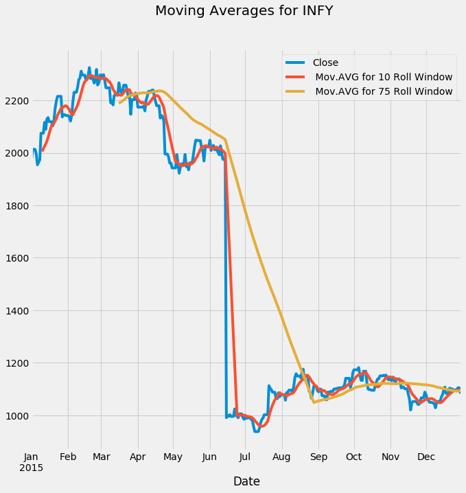

```python
plot_roll_win(INFY)
```

```
Calculated Moving Averages: for 10 weeks:

 Date
2015-01-01    11215.70
2015-01-02    11372.10
2015-01-03    11372.10
2015-01-04    11372.10
2015-01-05    11248.55
2015-01-06    10959.90
2015-01-07    10916.00
2015-01-08    11018.15
2015-01-09    11399.65
2015-01-10    11399.65
2015-01-11    11399.65
2015-01-12    11543.65
2015-01-13    11502.80
2015-01-14    11614.30
2015-01-15    11669.85
2015-01-16    11659.60
2015-01-17    11659.60
2015-01-18    11659.60
2015-01-19    11642.75
2015-01-20    11695.00
2015-01-21    11813.70
2015-01-22    11850.85
2015-01-23    11885.15
2015-01-24    11885.15
2015-01-25    11885.15
2015-01-26    11885.15
2015-01-27    11693.45
2015-01-28    11809.55
2015-01-29    11824.15
2015-01-30    11824.75
                ...
2015-12-02    11149.60
2015-12-03    11081.90
2015-12-04    10969.05
2015-12-05    10969.05
2015-12-06    10969.05
2015-12-07    10998.65
```

[output cut: 75 more lines]

```
2015-12-18    11122.50
2015-12-19    11122.50
2015-12-20    11122.50
2015-12-21    11224.75
2015-12-22    11095.45
2015-12-23    11195.65
2015-12-24    11184.90
2015-12-25    11184.90
2015-12-26    11184.90
2015-12-27    11184.90
2015-12-28    11271.80
2015-12-29    11253.45
2015-12-30    11117.60
2015-12-31    11212.55
Freq: D, Name: Close, dtype: float64
```

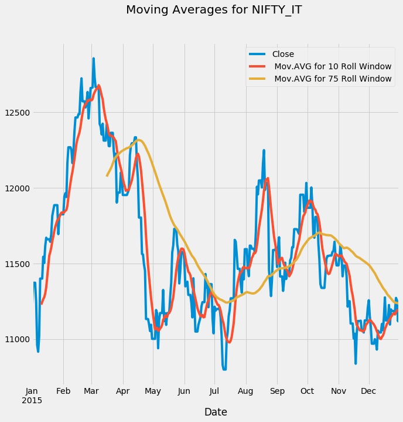

```python
plot_roll_win(NIFTY)
```

**Conclusion:** From Above graph plottings, we can visualize that, as much as the rolling window is small, the moving average is somehow significant and closer to the actual data

### Volume Shocks

```python
def volume_shocks(stock):
    """
    'Volume' - Vol_t
    'Volume next day - vol_t+1

    """
    stock["vol_t+1"] = stock.Volume.shift(1)  #next rows value

    stock["volume_shock"] = ((abs(stock["vol_t+1"] - stock["Volume"])/stock["Volume"]*100)  > 10).astype(int)

    return stock
```

```python
volume_shocks(TCS)
volume_shocks(INFY)
volume_shocks(NIFTY)
```

| Date | Date | Open | High | Low | Close | Volume | Turnover | Year | Month | Day | WeekOfYear | vol_t+1 | volume_shock |
| --- | --- | --- | --- | --- | --- | --- | --- | --- | --- | --- | --- | --- | --- |
| 2015-01-01 | 2015-01-01 | 11214.80 | 11235.75 | 11166.35 | 11215.70 | 4246150 | 3.575100e+09 | 2015 | 1 | 1 | 1 | NaN | 0 |
| 2015-01-02 | 2015-01-02 | 11214.65 | 11399.10 | 11214.65 | 11372.10 | 10004862 | 9.645600e+09 | 2015 | 1 | 2 | 1 | 4246150.0 | 1 |
| 2015-01-03 | 2015-01-02 | 11214.65 | 11399.10 | 11214.65 | 11372.10 | 10004862 | 9.645600e+09 | 2015 | 1 | 2 | 1 | 10004862.0 | 0 |
| 2015-01-04 | 2015-01-02 | 11214.65 | 11399.10 | 11214.65 | 11372.10 | 10004862 | 9.645600e+09 | 2015 | 1 | 2 | 1 | 10004862.0 | 0 |
| 2015-01-05 | 2015-01-05 | 11369.35 | 11433.75 | 11186.95 | 11248.55 | 8858018 | 1.059000e+10 | 2015 | 1 | 5 | 2 | 10004862.0 | 1 |
| 2015-01-06 | 2015-01-06 | 11186.10 | 11186.10 | 10909.00 | 10959.90 | 12515739 | 1.364500e+10 | 2015 | 1 | 6 | 2 | 8858018.0 | 1 |
| 2015-01-07 | 2015-01-07 | 11013.20 | 11042.35 | 10889.55 | 10916.00 | 10976356 | 1.203440e+10 | 2015 | 1 | 7 | 2 | 12515739.0 | 1 |
| 2015-01-08 | 2015-01-08 | 11031.15 | 11058.15 | 10915.05 | 11018.15 | 12975117 | 1.485630e+10 | 2015 | 1 | 8 | 2 | 10976356.0 | 1 |
| 2015-01-09 | 2015-01-09 | 11058.05 | 11484.90 | 10932.20 | 11399.65 | 24812224 | 3.536420e+10 | 2015 | 1 | 9 | 2 | 12975117.0 | 1 |
| 2015-01-10 | 2015-01-09 | 11058.05 | 11484.90 | 10932.20 | 11399.65 | 24812224 | 3.536420e+10 | 2015 | 1 | 9 | 2 | 24812224.0 | 0 |
| 2015-01-11 | 2015-01-09 | 11058.05 | 11484.90 | 10932.20 | 11399.65 | 24812224 | 3.536420e+10 | 2015 | 1 | 9 | 2 | 24812224.0 | 0 |
| 2015-01-12 | 2015-01-12 | 11456.00 | 11565.85 | 11378.80 | 11543.65 | 16505074 | 1.712310e+10 | 2015 | 1 | 12 | 3 | 24812224.0 | 1 |
| 2015-01-13 | 2015-01-13 | 11545.25 | 11546.60 | 11437.95 | 11502.80 | 12511358 | 1.417510e+10 | 2015 | 1 | 13 | 3 | 16505074.0 | 1 |
| 2015-01-14 | 2015-01-14 | 11561.95 | 11631.55 | 11521.00 | 11614.30 | 12544558 | 1.438530e+10 | 2015 | 1 | 14 | 3 | 12511358.0 | 0 |
| 2015-01-15 | 2015-01-15 | 11672.30 | 11774.50 | 11575.10 | 11669.85 | 13882213 | 1.764560e+10 | 2015 | 1 | 15 | 3 | 12544558.0 | 0 |
| 2015-01-16 | 2015-01-16 | 11708.85 | 11708.85 | 11582.85 | 11659.60 | 12368107 | 1.714690e+10 | 2015 | 1 | 16 | 3 | 13882213.0 | 1 |
| 2015-01-17 | 2015-01-16 | 11708.85 | 11708.85 | 11582.85 | 11659.60 | 12368107 | 1.714690e+10 | 2015 | 1 | 16 | 3 | 12368107.0 | 0 |
| 2015-01-18 | 2015-01-16 | 11708.85 | 11708.85 | 11582.85 | 11659.60 | 12368107 | 1.714690e+10 | 2015 | 1 | 16 | 3 | 12368107.0 | 0 |
| 2015-01-19 | 2015-01-19 | 11732.50 | 11797.60 | 11629.05 | 11642.75 | 13696381 | 1.183750e+10 | 2015 | 1 | 19 | 4 | 12368107.0 | 0 |
| 2015-01-20 | 2015-01-20 | 11681.80 | 11721.90 | 11635.70 | 11695.00 | 11021415 | 1.234730e+10 | 2015 | 1 | 20 | 4 | 13696381.0 | 1 |
| 2015-01-21 | 2015-01-21 | 11732.45 | 11838.30 | 11659.70 | 11813.70 | 18679282 | 1.973070e+10 | 2015 | 1 | 21 | 4 | 11021415.0 | 1 |
| 2015-01-22 | 2015-01-22 | 11832.55 | 11884.50 | 11782.95 | 11850.85 | 15715515 | 1.655670e+10 | 2015 | 1 | 22 | 4 | 18679282.0 | 1 |
| 2015-01-23 | 2015-01-23 | 11877.90 | 11921.00 | 11767.40 | 11885.15 | 30034833 | 2.001210e+10 | 2015 | 1 | 23 | 4 | 15715515.0 | 1 |
| 2015-01-24 | 2015-01-23 | 11877.90 | 11921.00 | 11767.40 | 11885.15 | 30034833 | 2.001210e+10 | 2015 | 1 | 23 | 4 | 30034833.0 | 0 |
| 2015-01-25 | 2015-01-23 | 11877.90 | 11921.00 | 11767.40 | 11885.15 | 30034833 | 2.001210e+10 | 2015 | 1 | 23 | 4 | 30034833.0 | 0 |
| 2015-01-26 | 2015-01-23 | 11877.90 | 11921.00 | 11767.40 | 11885.15 | 30034833 | 2.001210e+10 | 2015 | 1 | 23 | 4 | 30034833.0 | 0 |
| 2015-01-27 | 2015-01-27 | 11915.60 | 11917.25 | 11679.55 | 11693.45 | 17005337 | 1.866840e+10 | 2015 | 1 | 27 | 5 | 30034833.0 | 1 |
| 2015-01-28 | 2015-01-28 | 11712.55 | 11821.80 | 11693.80 | 11809.55 | 16876897 | 1.937590e+10 | 2015 | 1 | 28 | 5 | 17005337.0 | 0 |
| 2015-01-29 | 2015-01-29 | 11812.35 | 11861.50 | 11728.75 | 11824.15 | 15520902 | 2.160790e+10 | 2015 | 1 | 29 | 5 | 16876897.0 | 0 |
| 2015-01-30 | 2015-01-30 | 11998.35 | 12003.35 | 11799.35 | 11824.75 | 18559078 | 2.905950e+10 | 2015 | 1 | 30 | 5 | 15520902.0 | 1 |
| ... | ... | ... | ... | ... | ... | ... | ... | ... | ... | ... | ... | ... | ... |
| 2015-12-02 | 2015-12-02 | 11298.90 | 11298.90 | 11134.90 | 11149.60 | 7524996 | 8.086300e+09 | 2015 | 12 | 2 | 49 | 9112940.0 | 1 |
| 2015-12-03 | 2015-12-03 | 11149.30 | 11153.70 | 11067.55 | 11081.90 | 9384540 | 9.792900e+09 | 2015 | 12 | 3 | 49 | 7524996.0 | 1 |
| 2015-12-04 | 2015-12-04 | 11034.65 | 11037.95 | 10940.30 | 10969.05 | 10062731 | 9.755500e+09 | 2015 | 12 | 4 | 49 | 9384540.0 | 0 |
| 2015-12-05 | 2015-12-04 | 11034.65 | 11037.95 | 10940.30 | 10969.05 | 10062731 | 9.755500e+09 | 2015 | 12 | 4 | 49 | 10062731.0 | 0 |
| 2015-12-06 | 2015-12-04 | 11034.65 | 11037.95 | 10940.30 | 10969.05 | 10062731 | 9.755500e+09 | 2015 | 12 | 4 | 49 | 10062731.0 | 0 |
| 2015-12-07 | 2015-12-07 | 11009.50 | 11054.00 | 10943.85 | 10998.65 | 8477753 | 8.108600e+09 | 2015 | 12 | 7 | 50 | 10062731.0 | 1 |
| 2015-12-08 | 2015-12-08 | 10989.20 | 11109.30 | 10946.00 | 10981.85 | 8486760 | 8.256700e+09 | 2015 | 12 | 8 | 50 | 8477753.0 | 0 |
| 2015-12-09 | 2015-12-09 | 10978.25 | 11027.30 | 10916.25 | 10930.05 | 11006038 | 1.352400e+10 | 2015 | 12 | 9 | 50 | 8486760.0 | 1 |
| 2015-12-10 | 2015-12-10 | 10971.55 | 11073.15 | 10931.15 | 11055.50 | 7908231 | 8.326600e+09 | 2015 | 12 | 10 | 50 | 11006038.0 | 1 |
| 2015-12-11 | 2015-12-11 | 11086.55 | 11086.55 | 11015.60 | 11043.05 | 8502528 | 9.019600e+09 | 2015 | 12 | 11 | 50 | 7908231.0 | 0 |
| 2015-12-12 | 2015-12-11 | 11086.55 | 11086.55 | 11015.60 | 11043.05 | 8502528 | 9.019600e+09 | 2015 | 12 | 11 | 50 | 8502528.0 | 0 |
| 2015-12-13 | 2015-12-11 | 11086.55 | 11086.55 | 11015.60 | 11043.05 | 8502528 | 9.019600e+09 | 2015 | 12 | 11 | 50 | 8502528.0 | 0 |
| 2015-12-14 | 2015-12-14 | 10940.75 | 11124.90 | 10940.75 | 11099.70 | 7044052 | 8.280500e+09 | 2015 | 12 | 14 | 51 | 8502528.0 | 1 |
| 2015-12-15 | 2015-12-15 | 11139.55 | 11139.55 | 11044.35 | 11058.25 | 9065922 | 8.154000e+09 | 2015 | 12 | 15 | 51 | 7044052.0 | 1 |
| 2015-12-16 | 2015-12-16 | 11081.75 | 11187.85 | 11081.75 | 11144.90 | 8751937 | 8.490500e+09 | 2015 | 12 | 16 | 51 | 9065922.0 | 0 |
| 2015-12-17 | 2015-12-17 | 11182.95 | 11293.05 | 11122.45 | 11275.15 | 9556916 | 9.097200e+09 | 2015 | 12 | 17 | 51 | 8751937.0 | 0 |
| 2015-12-18 | 2015-12-18 | 11227.15 | 11227.15 | 11094.80 | 11122.50 | 11781399 | 1.222450e+10 | 2015 | 12 | 18 | 51 | 9556916.0 | 1 |
| 2015-12-19 | 2015-12-18 | 11227.15 | 11227.15 | 11094.80 | 11122.50 | 11781399 | 1.222450e+10 | 2015 | 12 | 18 | 51 | 11781399.0 | 0 |
| 2015-12-20 | 2015-12-18 | 11227.15 | 11227.15 | 11094.80 | 11122.50 | 11781399 | 1.222450e+10 | 2015 | 12 | 18 | 51 | 11781399.0 | 0 |
| 2015-12-21 | 2015-12-21 | 11096.40 | 11232.50 | 11067.20 | 11224.75 | 6043899 | 6.415600e+09 | 2015 | 12 | 21 | 52 | 11781399.0 | 1 |
| 2015-12-22 | 2015-12-22 | 11201.80 | 11201.80 | 11081.15 | 11095.45 | 5998230 | 6.366300e+09 | 2015 | 12 | 22 | 52 | 6043899.0 | 0 |
| 2015-12-23 | 2015-12-23 | 11163.80 | 11206.40 | 11130.65 | 11195.65 | 4638075 | 4.562900e+09 | 2015 | 12 | 23 | 52 | 5998230.0 | 1 |
| 2015-12-24 | 2015-12-24 | 11193.25 | 11197.50 | 11152.85 | 11184.90 | 2927864 | 3.182700e+09 | 2015 | 12 | 24 | 52 | 4638075.0 | 1 |
| 2015-12-25 | 2015-12-24 | 11193.25 | 11197.50 | 11152.85 | 11184.90 | 2927864 | 3.182700e+09 | 2015 | 12 | 24 | 52 | 2927864.0 | 0 |
| 2015-12-26 | 2015-12-24 | 11193.25 | 11197.50 | 11152.85 | 11184.90 | 2927864 | 3.182700e+09 | 2015 | 12 | 24 | 52 | 2927864.0 | 0 |
| 2015-12-27 | 2015-12-24 | 11193.25 | 11197.50 | 11152.85 | 11184.90 | 2927864 | 3.182700e+09 | 2015 | 12 | 24 | 52 | 2927864.0 | 0 |
| 2015-12-28 | 2015-12-28 | 11152.70 | 11303.05 | 11146.85 | 11271.80 | 8055590 | 1.001900e+10 | 2015 | 12 | 28 | 53 | 2927864.0 | 1 |
| 2015-12-29 | 2015-12-29 | 11257.05 | 11287.50 | 11206.60 | 11253.45 | 6024174 | 6.626200e+09 | 2015 | 12 | 29 | 53 | 8055590.0 | 1 |
| 2015-12-30 | 2015-12-30 | 11247.35 | 11263.60 | 11100.10 | 11117.60 | 6564991 | 7.071900e+09 | 2015 | 12 | 30 | 53 | 6024174.0 | 0 |
| 2015-12-31 | 2015-12-31 | 11113.00 | 11233.85 | 11113.00 | 11212.55 | 8197040 | 8.590500e+09 | 2015 | 12 | 31 | 53 | 6564991.0 | 1 |

365 rows × 13 columns

### VOLume Shock Direction

```python
def direction_fun(stock):

    # considerng only shock - 1 valued rows.
    # 0 - negative and 1- positive
    if stock["volume_shock"] == 0:
        pass
    else:
        if (stock["vol_t+1"] - stock["Volume"]) < 0:
            return 0
        else:
            return 1
```

```python
def vol_shock_direction(stock):
    stock['VOL_SHOCK_DIR'] = 'Nan'
    stock['VOL_SHOCK_DIR'] = stock.apply(direction_fun, axis=1)
    return stock
```

```python
vol_shock_direction(TCS)
vol_shock_direction(INFY)
vol_shock_direction(NIFTY)
```

| Date | Date | Open | High | Low | Close | Volume | Turnover | Year | Month | Day | WeekOfYear | vol_t+1 | volume_shock | VOL_SHOCK_DIR |
| --- | --- | --- | --- | --- | --- | --- | --- | --- | --- | --- | --- | --- | --- | --- |
| 2015-01-01 | 2015-01-01 | 11214.80 | 11235.75 | 11166.35 | 11215.70 | 4246150 | 3.575100e+09 | 2015 | 1 | 1 | 1 | NaN | 0 | NaN |
| 2015-01-02 | 2015-01-02 | 11214.65 | 11399.10 | 11214.65 | 11372.10 | 10004862 | 9.645600e+09 | 2015 | 1 | 2 | 1 | 4246150.0 | 1 | 0.0 |
| 2015-01-03 | 2015-01-02 | 11214.65 | 11399.10 | 11214.65 | 11372.10 | 10004862 | 9.645600e+09 | 2015 | 1 | 2 | 1 | 10004862.0 | 0 | NaN |
| 2015-01-04 | 2015-01-02 | 11214.65 | 11399.10 | 11214.65 | 11372.10 | 10004862 | 9.645600e+09 | 2015 | 1 | 2 | 1 | 10004862.0 | 0 | NaN |
| 2015-01-05 | 2015-01-05 | 11369.35 | 11433.75 | 11186.95 | 11248.55 | 8858018 | 1.059000e+10 | 2015 | 1 | 5 | 2 | 10004862.0 | 1 | 1.0 |
| 2015-01-06 | 2015-01-06 | 11186.10 | 11186.10 | 10909.00 | 10959.90 | 12515739 | 1.364500e+10 | 2015 | 1 | 6 | 2 | 8858018.0 | 1 | 0.0 |
| 2015-01-07 | 2015-01-07 | 11013.20 | 11042.35 | 10889.55 | 10916.00 | 10976356 | 1.203440e+10 | 2015 | 1 | 7 | 2 | 12515739.0 | 1 | 1.0 |
| 2015-01-08 | 2015-01-08 | 11031.15 | 11058.15 | 10915.05 | 11018.15 | 12975117 | 1.485630e+10 | 2015 | 1 | 8 | 2 | 10976356.0 | 1 | 0.0 |
| 2015-01-09 | 2015-01-09 | 11058.05 | 11484.90 | 10932.20 | 11399.65 | 24812224 | 3.536420e+10 | 2015 | 1 | 9 | 2 | 12975117.0 | 1 | 0.0 |
| 2015-01-10 | 2015-01-09 | 11058.05 | 11484.90 | 10932.20 | 11399.65 | 24812224 | 3.536420e+10 | 2015 | 1 | 9 | 2 | 24812224.0 | 0 | NaN |
| 2015-01-11 | 2015-01-09 | 11058.05 | 11484.90 | 10932.20 | 11399.65 | 24812224 | 3.536420e+10 | 2015 | 1 | 9 | 2 | 24812224.0 | 0 | NaN |
| 2015-01-12 | 2015-01-12 | 11456.00 | 11565.85 | 11378.80 | 11543.65 | 16505074 | 1.712310e+10 | 2015 | 1 | 12 | 3 | 24812224.0 | 1 | 1.0 |
| 2015-01-13 | 2015-01-13 | 11545.25 | 11546.60 | 11437.95 | 11502.80 | 12511358 | 1.417510e+10 | 2015 | 1 | 13 | 3 | 16505074.0 | 1 | 1.0 |
| 2015-01-14 | 2015-01-14 | 11561.95 | 11631.55 | 11521.00 | 11614.30 | 12544558 | 1.438530e+10 | 2015 | 1 | 14 | 3 | 12511358.0 | 0 | NaN |
| 2015-01-15 | 2015-01-15 | 11672.30 | 11774.50 | 11575.10 | 11669.85 | 13882213 | 1.764560e+10 | 2015 | 1 | 15 | 3 | 12544558.0 | 0 | NaN |
| 2015-01-16 | 2015-01-16 | 11708.85 | 11708.85 | 11582.85 | 11659.60 | 12368107 | 1.714690e+10 | 2015 | 1 | 16 | 3 | 13882213.0 | 1 | 1.0 |
| 2015-01-17 | 2015-01-16 | 11708.85 | 11708.85 | 11582.85 | 11659.60 | 12368107 | 1.714690e+10 | 2015 | 1 | 16 | 3 | 12368107.0 | 0 | NaN |
| 2015-01-18 | 2015-01-16 | 11708.85 | 11708.85 | 11582.85 | 11659.60 | 12368107 | 1.714690e+10 | 2015 | 1 | 16 | 3 | 12368107.0 | 0 | NaN |
| 2015-01-19 | 2015-01-19 | 11732.50 | 11797.60 | 11629.05 | 11642.75 | 13696381 | 1.183750e+10 | 2015 | 1 | 19 | 4 | 12368107.0 | 0 | NaN |
| 2015-01-20 | 2015-01-20 | 11681.80 | 11721.90 | 11635.70 | 11695.00 | 11021415 | 1.234730e+10 | 2015 | 1 | 20 | 4 | 13696381.0 | 1 | 1.0 |
| 2015-01-21 | 2015-01-21 | 11732.45 | 11838.30 | 11659.70 | 11813.70 | 18679282 | 1.973070e+10 | 2015 | 1 | 21 | 4 | 11021415.0 | 1 | 0.0 |
| 2015-01-22 | 2015-01-22 | 11832.55 | 11884.50 | 11782.95 | 11850.85 | 15715515 | 1.655670e+10 | 2015 | 1 | 22 | 4 | 18679282.0 | 1 | 1.0 |
| 2015-01-23 | 2015-01-23 | 11877.90 | 11921.00 | 11767.40 | 11885.15 | 30034833 | 2.001210e+10 | 2015 | 1 | 23 | 4 | 15715515.0 | 1 | 0.0 |
| 2015-01-24 | 2015-01-23 | 11877.90 | 11921.00 | 11767.40 | 11885.15 | 30034833 | 2.001210e+10 | 2015 | 1 | 23 | 4 | 30034833.0 | 0 | NaN |
| 2015-01-25 | 2015-01-23 | 11877.90 | 11921.00 | 11767.40 | 11885.15 | 30034833 | 2.001210e+10 | 2015 | 1 | 23 | 4 | 30034833.0 | 0 | NaN |
| 2015-01-26 | 2015-01-23 | 11877.90 | 11921.00 | 11767.40 | 11885.15 | 30034833 | 2.001210e+10 | 2015 | 1 | 23 | 4 | 30034833.0 | 0 | NaN |
| 2015-01-27 | 2015-01-27 | 11915.60 | 11917.25 | 11679.55 | 11693.45 | 17005337 | 1.866840e+10 | 2015 | 1 | 27 | 5 | 30034833.0 | 1 | 1.0 |
| 2015-01-28 | 2015-01-28 | 11712.55 | 11821.80 | 11693.80 | 11809.55 | 16876897 | 1.937590e+10 | 2015 | 1 | 28 | 5 | 17005337.0 | 0 | NaN |
| 2015-01-29 | 2015-01-29 | 11812.35 | 11861.50 | 11728.75 | 11824.15 | 15520902 | 2.160790e+10 | 2015 | 1 | 29 | 5 | 16876897.0 | 0 | NaN |
| 2015-01-30 | 2015-01-30 | 11998.35 | 12003.35 | 11799.35 | 11824.75 | 18559078 | 2.905950e+10 | 2015 | 1 | 30 | 5 | 15520902.0 | 1 | 0.0 |
| ... | ... | ... | ... | ... | ... | ... | ... | ... | ... | ... | ... | ... | ... | ... |
| 2015-12-02 | 2015-12-02 | 11298.90 | 11298.90 | 11134.90 | 11149.60 | 7524996 | 8.086300e+09 | 2015 | 12 | 2 | 49 | 9112940.0 | 1 | 1.0 |
| 2015-12-03 | 2015-12-03 | 11149.30 | 11153.70 | 11067.55 | 11081.90 | 9384540 | 9.792900e+09 | 2015 | 12 | 3 | 49 | 7524996.0 | 1 | 0.0 |
| 2015-12-04 | 2015-12-04 | 11034.65 | 11037.95 | 10940.30 | 10969.05 | 10062731 | 9.755500e+09 | 2015 | 12 | 4 | 49 | 9384540.0 | 0 | NaN |
| 2015-12-05 | 2015-12-04 | 11034.65 | 11037.95 | 10940.30 | 10969.05 | 10062731 | 9.755500e+09 | 2015 | 12 | 4 | 49 | 10062731.0 | 0 | NaN |
| 2015-12-06 | 2015-12-04 | 11034.65 | 11037.95 | 10940.30 | 10969.05 | 10062731 | 9.755500e+09 | 2015 | 12 | 4 | 49 | 10062731.0 | 0 | NaN |
| 2015-12-07 | 2015-12-07 | 11009.50 | 11054.00 | 10943.85 | 10998.65 | 8477753 | 8.108600e+09 | 2015 | 12 | 7 | 50 | 10062731.0 | 1 | 1.0 |
| 2015-12-08 | 2015-12-08 | 10989.20 | 11109.30 | 10946.00 | 10981.85 | 8486760 | 8.256700e+09 | 2015 | 12 | 8 | 50 | 8477753.0 | 0 | NaN |
| 2015-12-09 | 2015-12-09 | 10978.25 | 11027.30 | 10916.25 | 10930.05 | 11006038 | 1.352400e+10 | 2015 | 12 | 9 | 50 | 8486760.0 | 1 | 0.0 |
| 2015-12-10 | 2015-12-10 | 10971.55 | 11073.15 | 10931.15 | 11055.50 | 7908231 | 8.326600e+09 | 2015 | 12 | 10 | 50 | 11006038.0 | 1 | 1.0 |
| 2015-12-11 | 2015-12-11 | 11086.55 | 11086.55 | 11015.60 | 11043.05 | 8502528 | 9.019600e+09 | 2015 | 12 | 11 | 50 | 7908231.0 | 0 | NaN |
| 2015-12-12 | 2015-12-11 | 11086.55 | 11086.55 | 11015.60 | 11043.05 | 8502528 | 9.019600e+09 | 2015 | 12 | 11 | 50 | 8502528.0 | 0 | NaN |
| 2015-12-13 | 2015-12-11 | 11086.55 | 11086.55 | 11015.60 | 11043.05 | 8502528 | 9.019600e+09 | 2015 | 12 | 11 | 50 | 8502528.0 | 0 | NaN |
| 2015-12-14 | 2015-12-14 | 10940.75 | 11124.90 | 10940.75 | 11099.70 | 7044052 | 8.280500e+09 | 2015 | 12 | 14 | 51 | 8502528.0 | 1 | 1.0 |
| 2015-12-15 | 2015-12-15 | 11139.55 | 11139.55 | 11044.35 | 11058.25 | 9065922 | 8.154000e+09 | 2015 | 12 | 15 | 51 | 7044052.0 | 1 | 0.0 |
| 2015-12-16 | 2015-12-16 | 11081.75 | 11187.85 | 11081.75 | 11144.90 | 8751937 | 8.490500e+09 | 2015 | 12 | 16 | 51 | 9065922.0 | 0 | NaN |
| 2015-12-17 | 2015-12-17 | 11182.95 | 11293.05 | 11122.45 | 11275.15 | 9556916 | 9.097200e+09 | 2015 | 12 | 17 | 51 | 8751937.0 | 0 | NaN |
| 2015-12-18 | 2015-12-18 | 11227.15 | 11227.15 | 11094.80 | 11122.50 | 11781399 | 1.222450e+10 | 2015 | 12 | 18 | 51 | 9556916.0 | 1 | 0.0 |
| 2015-12-19 | 2015-12-18 | 11227.15 | 11227.15 | 11094.80 | 11122.50 | 11781399 | 1.222450e+10 | 2015 | 12 | 18 | 51 | 11781399.0 | 0 | NaN |
| 2015-12-20 | 2015-12-18 | 11227.15 | 11227.15 | 11094.80 | 11122.50 | 11781399 | 1.222450e+10 | 2015 | 12 | 18 | 51 | 11781399.0 | 0 | NaN |
| 2015-12-21 | 2015-12-21 | 11096.40 | 11232.50 | 11067.20 | 11224.75 | 6043899 | 6.415600e+09 | 2015 | 12 | 21 | 52 | 11781399.0 | 1 | 1.0 |
| 2015-12-22 | 2015-12-22 | 11201.80 | 11201.80 | 11081.15 | 11095.45 | 5998230 | 6.366300e+09 | 2015 | 12 | 22 | 52 | 6043899.0 | 0 | NaN |
| 2015-12-23 | 2015-12-23 | 11163.80 | 11206.40 | 11130.65 | 11195.65 | 4638075 | 4.562900e+09 | 2015 | 12 | 23 | 52 | 5998230.0 | 1 | 1.0 |
| 2015-12-24 | 2015-12-24 | 11193.25 | 11197.50 | 11152.85 | 11184.90 | 2927864 | 3.182700e+09 | 2015 | 12 | 24 | 52 | 4638075.0 | 1 | 1.0 |
| 2015-12-25 | 2015-12-24 | 11193.25 | 11197.50 | 11152.85 | 11184.90 | 2927864 | 3.182700e+09 | 2015 | 12 | 24 | 52 | 2927864.0 | 0 | NaN |
| 2015-12-26 | 2015-12-24 | 11193.25 | 11197.50 | 11152.85 | 11184.90 | 2927864 | 3.182700e+09 | 2015 | 12 | 24 | 52 | 2927864.0 | 0 | NaN |
| 2015-12-27 | 2015-12-24 | 11193.25 | 11197.50 | 11152.85 | 11184.90 | 2927864 | 3.182700e+09 | 2015 | 12 | 24 | 52 | 2927864.0 | 0 | NaN |
| 2015-12-28 | 2015-12-28 | 11152.70 | 11303.05 | 11146.85 | 11271.80 | 8055590 | 1.001900e+10 | 2015 | 12 | 28 | 53 | 2927864.0 | 1 | 0.0 |
| 2015-12-29 | 2015-12-29 | 11257.05 | 11287.50 | 11206.60 | 11253.45 | 6024174 | 6.626200e+09 | 2015 | 12 | 29 | 53 | 8055590.0 | 1 | 1.0 |
| 2015-12-30 | 2015-12-30 | 11247.35 | 11263.60 | 11100.10 | 11117.60 | 6564991 | 7.071900e+09 | 2015 | 12 | 30 | 53 | 6024174.0 | 0 | NaN |
| 2015-12-31 | 2015-12-31 | 11113.00 | 11233.85 | 11113.00 | 11212.55 | 8197040 | 8.590500e+09 | 2015 | 12 | 31 | 53 | 6564991.0 | 1 | 0.0 |

365 rows × 14 columns

### Price shocks

```python
def price_shocks(stock):
    """
    'ClosePrice' - Close_t
    'Close Price next day - vol_t+1

    """
    stock["price_t+1"] = stock.Close.shift(1)  #next rows value

    stock["price_shock"] = (abs((stock["price_t+1"] - stock["Close"])/stock["Close"]*100)  > 2).astype(int)

    stock["price_black_swan"] = stock['price_shock'] # Since both had same data anad info/

    return stock
```

```python
price_shocks(TCS)
price_shocks(INFY)
price_shocks(NIFTY)
```

| Date | Date | Open | High | Low | Close | Volume | Turnover | Year | Month | Day | WeekOfYear | vol_t+1 | volume_shock | VOL_SHOCK_DIR | price_t+1 | price_shock | price_black_swan |
| --- | --- | --- | --- | --- | --- | --- | --- | --- | --- | --- | --- | --- | --- | --- | --- | --- | --- |
| 2015-01-01 | 2015-01-01 | 11214.80 | 11235.75 | 11166.35 | 11215.70 | 4246150 | 3.575100e+09 | 2015 | 1 | 1 | 1 | NaN | 0 | NaN | NaN | 0 | 0 |
| 2015-01-02 | 2015-01-02 | 11214.65 | 11399.10 | 11214.65 | 11372.10 | 10004862 | 9.645600e+09 | 2015 | 1 | 2 | 1 | 4246150.0 | 1 | 0.0 | 11215.70 | 0 | 0 |
| 2015-01-03 | 2015-01-02 | 11214.65 | 11399.10 | 11214.65 | 11372.10 | 10004862 | 9.645600e+09 | 2015 | 1 | 2 | 1 | 10004862.0 | 0 | NaN | 11372.10 | 0 | 0 |
| 2015-01-04 | 2015-01-02 | 11214.65 | 11399.10 | 11214.65 | 11372.10 | 10004862 | 9.645600e+09 | 2015 | 1 | 2 | 1 | 10004862.0 | 0 | NaN | 11372.10 | 0 | 0 |
| 2015-01-05 | 2015-01-05 | 11369.35 | 11433.75 | 11186.95 | 11248.55 | 8858018 | 1.059000e+10 | 2015 | 1 | 5 | 2 | 10004862.0 | 1 | 1.0 | 11372.10 | 0 | 0 |
| 2015-01-06 | 2015-01-06 | 11186.10 | 11186.10 | 10909.00 | 10959.90 | 12515739 | 1.364500e+10 | 2015 | 1 | 6 | 2 | 8858018.0 | 1 | 0.0 | 11248.55 | 1 | 1 |
| 2015-01-07 | 2015-01-07 | 11013.20 | 11042.35 | 10889.55 | 10916.00 | 10976356 | 1.203440e+10 | 2015 | 1 | 7 | 2 | 12515739.0 | 1 | 1.0 | 10959.90 | 0 | 0 |
| 2015-01-08 | 2015-01-08 | 11031.15 | 11058.15 | 10915.05 | 11018.15 | 12975117 | 1.485630e+10 | 2015 | 1 | 8 | 2 | 10976356.0 | 1 | 0.0 | 10916.00 | 0 | 0 |
| 2015-01-09 | 2015-01-09 | 11058.05 | 11484.90 | 10932.20 | 11399.65 | 24812224 | 3.536420e+10 | 2015 | 1 | 9 | 2 | 12975117.0 | 1 | 0.0 | 11018.15 | 1 | 1 |
| 2015-01-10 | 2015-01-09 | 11058.05 | 11484.90 | 10932.20 | 11399.65 | 24812224 | 3.536420e+10 | 2015 | 1 | 9 | 2 | 24812224.0 | 0 | NaN | 11399.65 | 0 | 0 |
| 2015-01-11 | 2015-01-09 | 11058.05 | 11484.90 | 10932.20 | 11399.65 | 24812224 | 3.536420e+10 | 2015 | 1 | 9 | 2 | 24812224.0 | 0 | NaN | 11399.65 | 0 | 0 |
| 2015-01-12 | 2015-01-12 | 11456.00 | 11565.85 | 11378.80 | 11543.65 | 16505074 | 1.712310e+10 | 2015 | 1 | 12 | 3 | 24812224.0 | 1 | 1.0 | 11399.65 | 0 | 0 |
| 2015-01-13 | 2015-01-13 | 11545.25 | 11546.60 | 11437.95 | 11502.80 | 12511358 | 1.417510e+10 | 2015 | 1 | 13 | 3 | 16505074.0 | 1 | 1.0 | 11543.65 | 0 | 0 |
| 2015-01-14 | 2015-01-14 | 11561.95 | 11631.55 | 11521.00 | 11614.30 | 12544558 | 1.438530e+10 | 2015 | 1 | 14 | 3 | 12511358.0 | 0 | NaN | 11502.80 | 0 | 0 |
| 2015-01-15 | 2015-01-15 | 11672.30 | 11774.50 | 11575.10 | 11669.85 | 13882213 | 1.764560e+10 | 2015 | 1 | 15 | 3 | 12544558.0 | 0 | NaN | 11614.30 | 0 | 0 |
| 2015-01-16 | 2015-01-16 | 11708.85 | 11708.85 | 11582.85 | 11659.60 | 12368107 | 1.714690e+10 | 2015 | 1 | 16 | 3 | 13882213.0 | 1 | 1.0 | 11669.85 | 0 | 0 |
| 2015-01-17 | 2015-01-16 | 11708.85 | 11708.85 | 11582.85 | 11659.60 | 12368107 | 1.714690e+10 | 2015 | 1 | 16 | 3 | 12368107.0 | 0 | NaN | 11659.60 | 0 | 0 |
| 2015-01-18 | 2015-01-16 | 11708.85 | 11708.85 | 11582.85 | 11659.60 | 12368107 | 1.714690e+10 | 2015 | 1 | 16 | 3 | 12368107.0 | 0 | NaN | 11659.60 | 0 | 0 |
| 2015-01-19 | 2015-01-19 | 11732.50 | 11797.60 | 11629.05 | 11642.75 | 13696381 | 1.183750e+10 | 2015 | 1 | 19 | 4 | 12368107.0 | 0 | NaN | 11659.60 | 0 | 0 |
| 2015-01-20 | 2015-01-20 | 11681.80 | 11721.90 | 11635.70 | 11695.00 | 11021415 | 1.234730e+10 | 2015 | 1 | 20 | 4 | 13696381.0 | 1 | 1.0 | 11642.75 | 0 | 0 |
| 2015-01-21 | 2015-01-21 | 11732.45 | 11838.30 | 11659.70 | 11813.70 | 18679282 | 1.973070e+10 | 2015 | 1 | 21 | 4 | 11021415.0 | 1 | 0.0 | 11695.00 | 0 | 0 |
| 2015-01-22 | 2015-01-22 | 11832.55 | 11884.50 | 11782.95 | 11850.85 | 15715515 | 1.655670e+10 | 2015 | 1 | 22 | 4 | 18679282.0 | 1 | 1.0 | 11813.70 | 0 | 0 |
| 2015-01-23 | 2015-01-23 | 11877.90 | 11921.00 | 11767.40 | 11885.15 | 30034833 | 2.001210e+10 | 2015 | 1 | 23 | 4 | 15715515.0 | 1 | 0.0 | 11850.85 | 0 | 0 |
| 2015-01-24 | 2015-01-23 | 11877.90 | 11921.00 | 11767.40 | 11885.15 | 30034833 | 2.001210e+10 | 2015 | 1 | 23 | 4 | 30034833.0 | 0 | NaN | 11885.15 | 0 | 0 |
| 2015-01-25 | 2015-01-23 | 11877.90 | 11921.00 | 11767.40 | 11885.15 | 30034833 | 2.001210e+10 | 2015 | 1 | 23 | 4 | 30034833.0 | 0 | NaN | 11885.15 | 0 | 0 |
| 2015-01-26 | 2015-01-23 | 11877.90 | 11921.00 | 11767.40 | 11885.15 | 30034833 | 2.001210e+10 | 2015 | 1 | 23 | 4 | 30034833.0 | 0 | NaN | 11885.15 | 0 | 0 |
| 2015-01-27 | 2015-01-27 | 11915.60 | 11917.25 | 11679.55 | 11693.45 | 17005337 | 1.866840e+10 | 2015 | 1 | 27 | 5 | 30034833.0 | 1 | 1.0 | 11885.15 | 0 | 0 |
| 2015-01-28 | 2015-01-28 | 11712.55 | 11821.80 | 11693.80 | 11809.55 | 16876897 | 1.937590e+10 | 2015 | 1 | 28 | 5 | 17005337.0 | 0 | NaN | 11693.45 | 0 | 0 |
| 2015-01-29 | 2015-01-29 | 11812.35 | 11861.50 | 11728.75 | 11824.15 | 15520902 | 2.160790e+10 | 2015 | 1 | 29 | 5 | 16876897.0 | 0 | NaN | 11809.55 | 0 | 0 |
| 2015-01-30 | 2015-01-30 | 11998.35 | 12003.35 | 11799.35 | 11824.75 | 18559078 | 2.905950e+10 | 2015 | 1 | 30 | 5 | 15520902.0 | 1 | 0.0 | 11824.15 | 0 | 0 |
| ... | ... | ... | ... | ... | ... | ... | ... | ... | ... | ... | ... | ... | ... | ... | ... | ... | ... |
| 2015-12-02 | 2015-12-02 | 11298.90 | 11298.90 | 11134.90 | 11149.60 | 7524996 | 8.086300e+09 | 2015 | 12 | 2 | 49 | 9112940.0 | 1 | 1.0 | 11256.30 | 0 | 0 |
| 2015-12-03 | 2015-12-03 | 11149.30 | 11153.70 | 11067.55 | 11081.90 | 9384540 | 9.792900e+09 | 2015 | 12 | 3 | 49 | 7524996.0 | 1 | 0.0 | 11149.60 | 0 | 0 |
| 2015-12-04 | 2015-12-04 | 11034.65 | 11037.95 | 10940.30 | 10969.05 | 10062731 | 9.755500e+09 | 2015 | 12 | 4 | 49 | 9384540.0 | 0 | NaN | 11081.90 | 0 | 0 |
| 2015-12-05 | 2015-12-04 | 11034.65 | 11037.95 | 10940.30 | 10969.05 | 10062731 | 9.755500e+09 | 2015 | 12 | 4 | 49 | 10062731.0 | 0 | NaN | 10969.05 | 0 | 0 |
| 2015-12-06 | 2015-12-04 | 11034.65 | 11037.95 | 10940.30 | 10969.05 | 10062731 | 9.755500e+09 | 2015 | 12 | 4 | 49 | 10062731.0 | 0 | NaN | 10969.05 | 0 | 0 |
| 2015-12-07 | 2015-12-07 | 11009.50 | 11054.00 | 10943.85 | 10998.65 | 8477753 | 8.108600e+09 | 2015 | 12 | 7 | 50 | 10062731.0 | 1 | 1.0 | 10969.05 | 0 | 0 |
| 2015-12-08 | 2015-12-08 | 10989.20 | 11109.30 | 10946.00 | 10981.85 | 8486760 | 8.256700e+09 | 2015 | 12 | 8 | 50 | 8477753.0 | 0 | NaN | 10998.65 | 0 | 0 |
| 2015-12-09 | 2015-12-09 | 10978.25 | 11027.30 | 10916.25 | 10930.05 | 11006038 | 1.352400e+10 | 2015 | 12 | 9 | 50 | 8486760.0 | 1 | 0.0 | 10981.85 | 0 | 0 |
| 2015-12-10 | 2015-12-10 | 10971.55 | 11073.15 | 10931.15 | 11055.50 | 7908231 | 8.326600e+09 | 2015 | 12 | 10 | 50 | 11006038.0 | 1 | 1.0 | 10930.05 | 0 | 0 |
| 2015-12-11 | 2015-12-11 | 11086.55 | 11086.55 | 11015.60 | 11043.05 | 8502528 | 9.019600e+09 | 2015 | 12 | 11 | 50 | 7908231.0 | 0 | NaN | 11055.50 | 0 | 0 |
| 2015-12-12 | 2015-12-11 | 11086.55 | 11086.55 | 11015.60 | 11043.05 | 8502528 | 9.019600e+09 | 2015 | 12 | 11 | 50 | 8502528.0 | 0 | NaN | 11043.05 | 0 | 0 |
| 2015-12-13 | 2015-12-11 | 11086.55 | 11086.55 | 11015.60 | 11043.05 | 8502528 | 9.019600e+09 | 2015 | 12 | 11 | 50 | 8502528.0 | 0 | NaN | 11043.05 | 0 | 0 |
| 2015-12-14 | 2015-12-14 | 10940.75 | 11124.90 | 10940.75 | 11099.70 | 7044052 | 8.280500e+09 | 2015 | 12 | 14 | 51 | 8502528.0 | 1 | 1.0 | 11043.05 | 0 | 0 |
| 2015-12-15 | 2015-12-15 | 11139.55 | 11139.55 | 11044.35 | 11058.25 | 9065922 | 8.154000e+09 | 2015 | 12 | 15 | 51 | 7044052.0 | 1 | 0.0 | 11099.70 | 0 | 0 |
| 2015-12-16 | 2015-12-16 | 11081.75 | 11187.85 | 11081.75 | 11144.90 | 8751937 | 8.490500e+09 | 2015 | 12 | 16 | 51 | 9065922.0 | 0 | NaN | 11058.25 | 0 | 0 |
| 2015-12-17 | 2015-12-17 | 11182.95 | 11293.05 | 11122.45 | 11275.15 | 9556916 | 9.097200e+09 | 2015 | 12 | 17 | 51 | 8751937.0 | 0 | NaN | 11144.90 | 0 | 0 |
| 2015-12-18 | 2015-12-18 | 11227.15 | 11227.15 | 11094.80 | 11122.50 | 11781399 | 1.222450e+10 | 2015 | 12 | 18 | 51 | 9556916.0 | 1 | 0.0 | 11275.15 | 0 | 0 |
| 2015-12-19 | 2015-12-18 | 11227.15 | 11227.15 | 11094.80 | 11122.50 | 11781399 | 1.222450e+10 | 2015 | 12 | 18 | 51 | 11781399.0 | 0 | NaN | 11122.50 | 0 | 0 |
| 2015-12-20 | 2015-12-18 | 11227.15 | 11227.15 | 11094.80 | 11122.50 | 11781399 | 1.222450e+10 | 2015 | 12 | 18 | 51 | 11781399.0 | 0 | NaN | 11122.50 | 0 | 0 |
| 2015-12-21 | 2015-12-21 | 11096.40 | 11232.50 | 11067.20 | 11224.75 | 6043899 | 6.415600e+09 | 2015 | 12 | 21 | 52 | 11781399.0 | 1 | 1.0 | 11122.50 | 0 | 0 |
| 2015-12-22 | 2015-12-22 | 11201.80 | 11201.80 | 11081.15 | 11095.45 | 5998230 | 6.366300e+09 | 2015 | 12 | 22 | 52 | 6043899.0 | 0 | NaN | 11224.75 | 0 | 0 |
| 2015-12-23 | 2015-12-23 | 11163.80 | 11206.40 | 11130.65 | 11195.65 | 4638075 | 4.562900e+09 | 2015 | 12 | 23 | 52 | 5998230.0 | 1 | 1.0 | 11095.45 | 0 | 0 |
| 2015-12-24 | 2015-12-24 | 11193.25 | 11197.50 | 11152.85 | 11184.90 | 2927864 | 3.182700e+09 | 2015 | 12 | 24 | 52 | 4638075.0 | 1 | 1.0 | 11195.65 | 0 | 0 |
| 2015-12-25 | 2015-12-24 | 11193.25 | 11197.50 | 11152.85 | 11184.90 | 2927864 | 3.182700e+09 | 2015 | 12 | 24 | 52 | 2927864.0 | 0 | NaN | 11184.90 | 0 | 0 |
| 2015-12-26 | 2015-12-24 | 11193.25 | 11197.50 | 11152.85 | 11184.90 | 2927864 | 3.182700e+09 | 2015 | 12 | 24 | 52 | 2927864.0 | 0 | NaN | 11184.90 | 0 | 0 |
| 2015-12-27 | 2015-12-24 | 11193.25 | 11197.50 | 11152.85 | 11184.90 | 2927864 | 3.182700e+09 | 2015 | 12 | 24 | 52 | 2927864.0 | 0 | NaN | 11184.90 | 0 | 0 |
| 2015-12-28 | 2015-12-28 | 11152.70 | 11303.05 | 11146.85 | 11271.80 | 8055590 | 1.001900e+10 | 2015 | 12 | 28 | 53 | 2927864.0 | 1 | 0.0 | 11184.90 | 0 | 0 |
| 2015-12-29 | 2015-12-29 | 11257.05 | 11287.50 | 11206.60 | 11253.45 | 6024174 | 6.626200e+09 | 2015 | 12 | 29 | 53 | 8055590.0 | 1 | 1.0 | 11271.80 | 0 | 0 |
| 2015-12-30 | 2015-12-30 | 11247.35 | 11263.60 | 11100.10 | 11117.60 | 6564991 | 7.071900e+09 | 2015 | 12 | 30 | 53 | 6024174.0 | 0 | NaN | 11253.45 | 0 | 0 |
| 2015-12-31 | 2015-12-31 | 11113.00 | 11233.85 | 11113.00 | 11212.55 | 8197040 | 8.590500e+09 | 2015 | 12 | 31 | 53 | 6564991.0 | 1 | 0.0 | 11117.60 | 0 | 0 |

365 rows × 17 columns

```python
def direction_fun_price(stock):

    # considerng only shock - 1 valued rows.
    # 0 - negative and 1- positive
    if stock["price_shock"] == 0:
        pass
    else:
        if (stock["price_t+1"] - stock["Close"]) < 0:
            return 0
        else:
            return 1
```

```python
def price_shock_direction(stock):
    stock['PRICE_SHOCK_DIR'] = 'Nan'
    stock['PRICE_SHOCK_DIR'] = stock.apply(direction_fun_price, axis=1)
    return stock
```

```python
vol_shock_direction(TCS)
vol_shock_direction(INFY)
vol_shock_direction(NIFTY)
```

| Date | Date | Open | High | Low | Close | Volume | Turnover | Year | Month | Day | WeekOfYear | vol_t+1 | volume_shock | VOL_SHOCK_DIR | price_t+1 | price_shock | price_black_swan |
| --- | --- | --- | --- | --- | --- | --- | --- | --- | --- | --- | --- | --- | --- | --- | --- | --- | --- |
| 2015-01-01 | 2015-01-01 | 11214.80 | 11235.75 | 11166.35 | 11215.70 | 4246150 | 3.575100e+09 | 2015 | 1 | 1 | 1 | NaN | 0 | NaN | NaN | 0 | 0 |
| 2015-01-02 | 2015-01-02 | 11214.65 | 11399.10 | 11214.65 | 11372.10 | 10004862 | 9.645600e+09 | 2015 | 1 | 2 | 1 | 4246150.0 | 1 | 0.0 | 11215.70 | 0 | 0 |
| 2015-01-03 | 2015-01-02 | 11214.65 | 11399.10 | 11214.65 | 11372.10 | 10004862 | 9.645600e+09 | 2015 | 1 | 2 | 1 | 10004862.0 | 0 | NaN | 11372.10 | 0 | 0 |
| 2015-01-04 | 2015-01-02 | 11214.65 | 11399.10 | 11214.65 | 11372.10 | 10004862 | 9.645600e+09 | 2015 | 1 | 2 | 1 | 10004862.0 | 0 | NaN | 11372.10 | 0 | 0 |
| 2015-01-05 | 2015-01-05 | 11369.35 | 11433.75 | 11186.95 | 11248.55 | 8858018 | 1.059000e+10 | 2015 | 1 | 5 | 2 | 10004862.0 | 1 | 1.0 | 11372.10 | 0 | 0 |
| 2015-01-06 | 2015-01-06 | 11186.10 | 11186.10 | 10909.00 | 10959.90 | 12515739 | 1.364500e+10 | 2015 | 1 | 6 | 2 | 8858018.0 | 1 | 0.0 | 11248.55 | 1 | 1 |
| 2015-01-07 | 2015-01-07 | 11013.20 | 11042.35 | 10889.55 | 10916.00 | 10976356 | 1.203440e+10 | 2015 | 1 | 7 | 2 | 12515739.0 | 1 | 1.0 | 10959.90 | 0 | 0 |
| 2015-01-08 | 2015-01-08 | 11031.15 | 11058.15 | 10915.05 | 11018.15 | 12975117 | 1.485630e+10 | 2015 | 1 | 8 | 2 | 10976356.0 | 1 | 0.0 | 10916.00 | 0 | 0 |
| 2015-01-09 | 2015-01-09 | 11058.05 | 11484.90 | 10932.20 | 11399.65 | 24812224 | 3.536420e+10 | 2015 | 1 | 9 | 2 | 12975117.0 | 1 | 0.0 | 11018.15 | 1 | 1 |
| 2015-01-10 | 2015-01-09 | 11058.05 | 11484.90 | 10932.20 | 11399.65 | 24812224 | 3.536420e+10 | 2015 | 1 | 9 | 2 | 24812224.0 | 0 | NaN | 11399.65 | 0 | 0 |
| 2015-01-11 | 2015-01-09 | 11058.05 | 11484.90 | 10932.20 | 11399.65 | 24812224 | 3.536420e+10 | 2015 | 1 | 9 | 2 | 24812224.0 | 0 | NaN | 11399.65 | 0 | 0 |
| 2015-01-12 | 2015-01-12 | 11456.00 | 11565.85 | 11378.80 | 11543.65 | 16505074 | 1.712310e+10 | 2015 | 1 | 12 | 3 | 24812224.0 | 1 | 1.0 | 11399.65 | 0 | 0 |
| 2015-01-13 | 2015-01-13 | 11545.25 | 11546.60 | 11437.95 | 11502.80 | 12511358 | 1.417510e+10 | 2015 | 1 | 13 | 3 | 16505074.0 | 1 | 1.0 | 11543.65 | 0 | 0 |
| 2015-01-14 | 2015-01-14 | 11561.95 | 11631.55 | 11521.00 | 11614.30 | 12544558 | 1.438530e+10 | 2015 | 1 | 14 | 3 | 12511358.0 | 0 | NaN | 11502.80 | 0 | 0 |
| 2015-01-15 | 2015-01-15 | 11672.30 | 11774.50 | 11575.10 | 11669.85 | 13882213 | 1.764560e+10 | 2015 | 1 | 15 | 3 | 12544558.0 | 0 | NaN | 11614.30 | 0 | 0 |
| 2015-01-16 | 2015-01-16 | 11708.85 | 11708.85 | 11582.85 | 11659.60 | 12368107 | 1.714690e+10 | 2015 | 1 | 16 | 3 | 13882213.0 | 1 | 1.0 | 11669.85 | 0 | 0 |
| 2015-01-17 | 2015-01-16 | 11708.85 | 11708.85 | 11582.85 | 11659.60 | 12368107 | 1.714690e+10 | 2015 | 1 | 16 | 3 | 12368107.0 | 0 | NaN | 11659.60 | 0 | 0 |
| 2015-01-18 | 2015-01-16 | 11708.85 | 11708.85 | 11582.85 | 11659.60 | 12368107 | 1.714690e+10 | 2015 | 1 | 16 | 3 | 12368107.0 | 0 | NaN | 11659.60 | 0 | 0 |
| 2015-01-19 | 2015-01-19 | 11732.50 | 11797.60 | 11629.05 | 11642.75 | 13696381 | 1.183750e+10 | 2015 | 1 | 19 | 4 | 12368107.0 | 0 | NaN | 11659.60 | 0 | 0 |
| 2015-01-20 | 2015-01-20 | 11681.80 | 11721.90 | 11635.70 | 11695.00 | 11021415 | 1.234730e+10 | 2015 | 1 | 20 | 4 | 13696381.0 | 1 | 1.0 | 11642.75 | 0 | 0 |
| 2015-01-21 | 2015-01-21 | 11732.45 | 11838.30 | 11659.70 | 11813.70 | 18679282 | 1.973070e+10 | 2015 | 1 | 21 | 4 | 11021415.0 | 1 | 0.0 | 11695.00 | 0 | 0 |
| 2015-01-22 | 2015-01-22 | 11832.55 | 11884.50 | 11782.95 | 11850.85 | 15715515 | 1.655670e+10 | 2015 | 1 | 22 | 4 | 18679282.0 | 1 | 1.0 | 11813.70 | 0 | 0 |
| 2015-01-23 | 2015-01-23 | 11877.90 | 11921.00 | 11767.40 | 11885.15 | 30034833 | 2.001210e+10 | 2015 | 1 | 23 | 4 | 15715515.0 | 1 | 0.0 | 11850.85 | 0 | 0 |
| 2015-01-24 | 2015-01-23 | 11877.90 | 11921.00 | 11767.40 | 11885.15 | 30034833 | 2.001210e+10 | 2015 | 1 | 23 | 4 | 30034833.0 | 0 | NaN | 11885.15 | 0 | 0 |
| 2015-01-25 | 2015-01-23 | 11877.90 | 11921.00 | 11767.40 | 11885.15 | 30034833 | 2.001210e+10 | 2015 | 1 | 23 | 4 | 30034833.0 | 0 | NaN | 11885.15 | 0 | 0 |
| 2015-01-26 | 2015-01-23 | 11877.90 | 11921.00 | 11767.40 | 11885.15 | 30034833 | 2.001210e+10 | 2015 | 1 | 23 | 4 | 30034833.0 | 0 | NaN | 11885.15 | 0 | 0 |
| 2015-01-27 | 2015-01-27 | 11915.60 | 11917.25 | 11679.55 | 11693.45 | 17005337 | 1.866840e+10 | 2015 | 1 | 27 | 5 | 30034833.0 | 1 | 1.0 | 11885.15 | 0 | 0 |
| 2015-01-28 | 2015-01-28 | 11712.55 | 11821.80 | 11693.80 | 11809.55 | 16876897 | 1.937590e+10 | 2015 | 1 | 28 | 5 | 17005337.0 | 0 | NaN | 11693.45 | 0 | 0 |
| 2015-01-29 | 2015-01-29 | 11812.35 | 11861.50 | 11728.75 | 11824.15 | 15520902 | 2.160790e+10 | 2015 | 1 | 29 | 5 | 16876897.0 | 0 | NaN | 11809.55 | 0 | 0 |
| 2015-01-30 | 2015-01-30 | 11998.35 | 12003.35 | 11799.35 | 11824.75 | 18559078 | 2.905950e+10 | 2015 | 1 | 30 | 5 | 15520902.0 | 1 | 0.0 | 11824.15 | 0 | 0 |
| ... | ... | ... | ... | ... | ... | ... | ... | ... | ... | ... | ... | ... | ... | ... | ... | ... | ... |
| 2015-12-02 | 2015-12-02 | 11298.90 | 11298.90 | 11134.90 | 11149.60 | 7524996 | 8.086300e+09 | 2015 | 12 | 2 | 49 | 9112940.0 | 1 | 1.0 | 11256.30 | 0 | 0 |
| 2015-12-03 | 2015-12-03 | 11149.30 | 11153.70 | 11067.55 | 11081.90 | 9384540 | 9.792900e+09 | 2015 | 12 | 3 | 49 | 7524996.0 | 1 | 0.0 | 11149.60 | 0 | 0 |
| 2015-12-04 | 2015-12-04 | 11034.65 | 11037.95 | 10940.30 | 10969.05 | 10062731 | 9.755500e+09 | 2015 | 12 | 4 | 49 | 9384540.0 | 0 | NaN | 11081.90 | 0 | 0 |
| 2015-12-05 | 2015-12-04 | 11034.65 | 11037.95 | 10940.30 | 10969.05 | 10062731 | 9.755500e+09 | 2015 | 12 | 4 | 49 | 10062731.0 | 0 | NaN | 10969.05 | 0 | 0 |
| 2015-12-06 | 2015-12-04 | 11034.65 | 11037.95 | 10940.30 | 10969.05 | 10062731 | 9.755500e+09 | 2015 | 12 | 4 | 49 | 10062731.0 | 0 | NaN | 10969.05 | 0 | 0 |
| 2015-12-07 | 2015-12-07 | 11009.50 | 11054.00 | 10943.85 | 10998.65 | 8477753 | 8.108600e+09 | 2015 | 12 | 7 | 50 | 10062731.0 | 1 | 1.0 | 10969.05 | 0 | 0 |
| 2015-12-08 | 2015-12-08 | 10989.20 | 11109.30 | 10946.00 | 10981.85 | 8486760 | 8.256700e+09 | 2015 | 12 | 8 | 50 | 8477753.0 | 0 | NaN | 10998.65 | 0 | 0 |
| 2015-12-09 | 2015-12-09 | 10978.25 | 11027.30 | 10916.25 | 10930.05 | 11006038 | 1.352400e+10 | 2015 | 12 | 9 | 50 | 8486760.0 | 1 | 0.0 | 10981.85 | 0 | 0 |
| 2015-12-10 | 2015-12-10 | 10971.55 | 11073.15 | 10931.15 | 11055.50 | 7908231 | 8.326600e+09 | 2015 | 12 | 10 | 50 | 11006038.0 | 1 | 1.0 | 10930.05 | 0 | 0 |
| 2015-12-11 | 2015-12-11 | 11086.55 | 11086.55 | 11015.60 | 11043.05 | 8502528 | 9.019600e+09 | 2015 | 12 | 11 | 50 | 7908231.0 | 0 | NaN | 11055.50 | 0 | 0 |
| 2015-12-12 | 2015-12-11 | 11086.55 | 11086.55 | 11015.60 | 11043.05 | 8502528 | 9.019600e+09 | 2015 | 12 | 11 | 50 | 8502528.0 | 0 | NaN | 11043.05 | 0 | 0 |
| 2015-12-13 | 2015-12-11 | 11086.55 | 11086.55 | 11015.60 | 11043.05 | 8502528 | 9.019600e+09 | 2015 | 12 | 11 | 50 | 8502528.0 | 0 | NaN | 11043.05 | 0 | 0 |
| 2015-12-14 | 2015-12-14 | 10940.75 | 11124.90 | 10940.75 | 11099.70 | 7044052 | 8.280500e+09 | 2015 | 12 | 14 | 51 | 8502528.0 | 1 | 1.0 | 11043.05 | 0 | 0 |
| 2015-12-15 | 2015-12-15 | 11139.55 | 11139.55 | 11044.35 | 11058.25 | 9065922 | 8.154000e+09 | 2015 | 12 | 15 | 51 | 7044052.0 | 1 | 0.0 | 11099.70 | 0 | 0 |
| 2015-12-16 | 2015-12-16 | 11081.75 | 11187.85 | 11081.75 | 11144.90 | 8751937 | 8.490500e+09 | 2015 | 12 | 16 | 51 | 9065922.0 | 0 | NaN | 11058.25 | 0 | 0 |
| 2015-12-17 | 2015-12-17 | 11182.95 | 11293.05 | 11122.45 | 11275.15 | 9556916 | 9.097200e+09 | 2015 | 12 | 17 | 51 | 8751937.0 | 0 | NaN | 11144.90 | 0 | 0 |
| 2015-12-18 | 2015-12-18 | 11227.15 | 11227.15 | 11094.80 | 11122.50 | 11781399 | 1.222450e+10 | 2015 | 12 | 18 | 51 | 9556916.0 | 1 | 0.0 | 11275.15 | 0 | 0 |
| 2015-12-19 | 2015-12-18 | 11227.15 | 11227.15 | 11094.80 | 11122.50 | 11781399 | 1.222450e+10 | 2015 | 12 | 18 | 51 | 11781399.0 | 0 | NaN | 11122.50 | 0 | 0 |
| 2015-12-20 | 2015-12-18 | 11227.15 | 11227.15 | 11094.80 | 11122.50 | 11781399 | 1.222450e+10 | 2015 | 12 | 18 | 51 | 11781399.0 | 0 | NaN | 11122.50 | 0 | 0 |
| 2015-12-21 | 2015-12-21 | 11096.40 | 11232.50 | 11067.20 | 11224.75 | 6043899 | 6.415600e+09 | 2015 | 12 | 21 | 52 | 11781399.0 | 1 | 1.0 | 11122.50 | 0 | 0 |
| 2015-12-22 | 2015-12-22 | 11201.80 | 11201.80 | 11081.15 | 11095.45 | 5998230 | 6.366300e+09 | 2015 | 12 | 22 | 52 | 6043899.0 | 0 | NaN | 11224.75 | 0 | 0 |
| 2015-12-23 | 2015-12-23 | 11163.80 | 11206.40 | 11130.65 | 11195.65 | 4638075 | 4.562900e+09 | 2015 | 12 | 23 | 52 | 5998230.0 | 1 | 1.0 | 11095.45 | 0 | 0 |
| 2015-12-24 | 2015-12-24 | 11193.25 | 11197.50 | 11152.85 | 11184.90 | 2927864 | 3.182700e+09 | 2015 | 12 | 24 | 52 | 4638075.0 | 1 | 1.0 | 11195.65 | 0 | 0 |
| 2015-12-25 | 2015-12-24 | 11193.25 | 11197.50 | 11152.85 | 11184.90 | 2927864 | 3.182700e+09 | 2015 | 12 | 24 | 52 | 2927864.0 | 0 | NaN | 11184.90 | 0 | 0 |
| 2015-12-26 | 2015-12-24 | 11193.25 | 11197.50 | 11152.85 | 11184.90 | 2927864 | 3.182700e+09 | 2015 | 12 | 24 | 52 | 2927864.0 | 0 | NaN | 11184.90 | 0 | 0 |
| 2015-12-27 | 2015-12-24 | 11193.25 | 11197.50 | 11152.85 | 11184.90 | 2927864 | 3.182700e+09 | 2015 | 12 | 24 | 52 | 2927864.0 | 0 | NaN | 11184.90 | 0 | 0 |
| 2015-12-28 | 2015-12-28 | 11152.70 | 11303.05 | 11146.85 | 11271.80 | 8055590 | 1.001900e+10 | 2015 | 12 | 28 | 53 | 2927864.0 | 1 | 0.0 | 11184.90 | 0 | 0 |
| 2015-12-29 | 2015-12-29 | 11257.05 | 11287.50 | 11206.60 | 11253.45 | 6024174 | 6.626200e+09 | 2015 | 12 | 29 | 53 | 8055590.0 | 1 | 1.0 | 11271.80 | 0 | 0 |
| 2015-12-30 | 2015-12-30 | 11247.35 | 11263.60 | 11100.10 | 11117.60 | 6564991 | 7.071900e+09 | 2015 | 12 | 30 | 53 | 6024174.0 | 0 | NaN | 11253.45 | 0 | 0 |
| 2015-12-31 | 2015-12-31 | 11113.00 | 11233.85 | 11113.00 | 11212.55 | 8197040 | 8.590500e+09 | 2015 | 12 | 31 | 53 | 6564991.0 | 1 | 0.0 | 11117.60 | 0 | 0 |

365 rows × 17 columns

### Price Shock w/o volume shocks

```python
def price_shock_wo_vol_shock(stock):

    stock["not_vol_shock"]  = (~(stock["volume_shock"].astype(bool))).astype(int)
    stock["price_shock_w/0_vol_shock"] = stock["not_vol_shock"] & stock["price_shock"]

    return stock
```

```python
price_shock_wo_vol_shock(TCS)
price_shock_wo_vol_shock(INFY)
price_shock_wo_vol_shock(NIFTY)
```

| Date | Date | Open | High | Low | Close | Volume | Turnover | Year | Month | Day | WeekOfYear | vol_t+1 | volume_shock | VOL_SHOCK_DIR | price_t+1 | price_shock | price_black_swan | not_vol_shock | price_shock_w/0_vol_shock |
| --- | --- | --- | --- | --- | --- | --- | --- | --- | --- | --- | --- | --- | --- | --- | --- | --- | --- | --- | --- |
| 2015-01-01 | 2015-01-01 | 11214.80 | 11235.75 | 11166.35 | 11215.70 | 4246150 | 3.575100e+09 | 2015 | 1 | 1 | 1 | NaN | 0 | NaN | NaN | 0 | 0 | 1 | 0 |
| 2015-01-02 | 2015-01-02 | 11214.65 | 11399.10 | 11214.65 | 11372.10 | 10004862 | 9.645600e+09 | 2015 | 1 | 2 | 1 | 4246150.0 | 1 | 0.0 | 11215.70 | 0 | 0 | 0 | 0 |
| 2015-01-03 | 2015-01-02 | 11214.65 | 11399.10 | 11214.65 | 11372.10 | 10004862 | 9.645600e+09 | 2015 | 1 | 2 | 1 | 10004862.0 | 0 | NaN | 11372.10 | 0 | 0 | 1 | 0 |
| 2015-01-04 | 2015-01-02 | 11214.65 | 11399.10 | 11214.65 | 11372.10 | 10004862 | 9.645600e+09 | 2015 | 1 | 2 | 1 | 10004862.0 | 0 | NaN | 11372.10 | 0 | 0 | 1 | 0 |
| 2015-01-05 | 2015-01-05 | 11369.35 | 11433.75 | 11186.95 | 11248.55 | 8858018 | 1.059000e+10 | 2015 | 1 | 5 | 2 | 10004862.0 | 1 | 1.0 | 11372.10 | 0 | 0 | 0 | 0 |
| 2015-01-06 | 2015-01-06 | 11186.10 | 11186.10 | 10909.00 | 10959.90 | 12515739 | 1.364500e+10 | 2015 | 1 | 6 | 2 | 8858018.0 | 1 | 0.0 | 11248.55 | 1 | 1 | 0 | 0 |
| 2015-01-07 | 2015-01-07 | 11013.20 | 11042.35 | 10889.55 | 10916.00 | 10976356 | 1.203440e+10 | 2015 | 1 | 7 | 2 | 12515739.0 | 1 | 1.0 | 10959.90 | 0 | 0 | 0 | 0 |
| 2015-01-08 | 2015-01-08 | 11031.15 | 11058.15 | 10915.05 | 11018.15 | 12975117 | 1.485630e+10 | 2015 | 1 | 8 | 2 | 10976356.0 | 1 | 0.0 | 10916.00 | 0 | 0 | 0 | 0 |
| 2015-01-09 | 2015-01-09 | 11058.05 | 11484.90 | 10932.20 | 11399.65 | 24812224 | 3.536420e+10 | 2015 | 1 | 9 | 2 | 12975117.0 | 1 | 0.0 | 11018.15 | 1 | 1 | 0 | 0 |
| 2015-01-10 | 2015-01-09 | 11058.05 | 11484.90 | 10932.20 | 11399.65 | 24812224 | 3.536420e+10 | 2015 | 1 | 9 | 2 | 24812224.0 | 0 | NaN | 11399.65 | 0 | 0 | 1 | 0 |
| 2015-01-11 | 2015-01-09 | 11058.05 | 11484.90 | 10932.20 | 11399.65 | 24812224 | 3.536420e+10 | 2015 | 1 | 9 | 2 | 24812224.0 | 0 | NaN | 11399.65 | 0 | 0 | 1 | 0 |
| 2015-01-12 | 2015-01-12 | 11456.00 | 11565.85 | 11378.80 | 11543.65 | 16505074 | 1.712310e+10 | 2015 | 1 | 12 | 3 | 24812224.0 | 1 | 1.0 | 11399.65 | 0 | 0 | 0 | 0 |
| 2015-01-13 | 2015-01-13 | 11545.25 | 11546.60 | 11437.95 | 11502.80 | 12511358 | 1.417510e+10 | 2015 | 1 | 13 | 3 | 16505074.0 | 1 | 1.0 | 11543.65 | 0 | 0 | 0 | 0 |
| 2015-01-14 | 2015-01-14 | 11561.95 | 11631.55 | 11521.00 | 11614.30 | 12544558 | 1.438530e+10 | 2015 | 1 | 14 | 3 | 12511358.0 | 0 | NaN | 11502.80 | 0 | 0 | 1 | 0 |
| 2015-01-15 | 2015-01-15 | 11672.30 | 11774.50 | 11575.10 | 11669.85 | 13882213 | 1.764560e+10 | 2015 | 1 | 15 | 3 | 12544558.0 | 0 | NaN | 11614.30 | 0 | 0 | 1 | 0 |
| 2015-01-16 | 2015-01-16 | 11708.85 | 11708.85 | 11582.85 | 11659.60 | 12368107 | 1.714690e+10 | 2015 | 1 | 16 | 3 | 13882213.0 | 1 | 1.0 | 11669.85 | 0 | 0 | 0 | 0 |
| 2015-01-17 | 2015-01-16 | 11708.85 | 11708.85 | 11582.85 | 11659.60 | 12368107 | 1.714690e+10 | 2015 | 1 | 16 | 3 | 12368107.0 | 0 | NaN | 11659.60 | 0 | 0 | 1 | 0 |
| 2015-01-18 | 2015-01-16 | 11708.85 | 11708.85 | 11582.85 | 11659.60 | 12368107 | 1.714690e+10 | 2015 | 1 | 16 | 3 | 12368107.0 | 0 | NaN | 11659.60 | 0 | 0 | 1 | 0 |
| 2015-01-19 | 2015-01-19 | 11732.50 | 11797.60 | 11629.05 | 11642.75 | 13696381 | 1.183750e+10 | 2015 | 1 | 19 | 4 | 12368107.0 | 0 | NaN | 11659.60 | 0 | 0 | 1 | 0 |
| 2015-01-20 | 2015-01-20 | 11681.80 | 11721.90 | 11635.70 | 11695.00 | 11021415 | 1.234730e+10 | 2015 | 1 | 20 | 4 | 13696381.0 | 1 | 1.0 | 11642.75 | 0 | 0 | 0 | 0 |
| 2015-01-21 | 2015-01-21 | 11732.45 | 11838.30 | 11659.70 | 11813.70 | 18679282 | 1.973070e+10 | 2015 | 1 | 21 | 4 | 11021415.0 | 1 | 0.0 | 11695.00 | 0 | 0 | 0 | 0 |
| 2015-01-22 | 2015-01-22 | 11832.55 | 11884.50 | 11782.95 | 11850.85 | 15715515 | 1.655670e+10 | 2015 | 1 | 22 | 4 | 18679282.0 | 1 | 1.0 | 11813.70 | 0 | 0 | 0 | 0 |
| 2015-01-23 | 2015-01-23 | 11877.90 | 11921.00 | 11767.40 | 11885.15 | 30034833 | 2.001210e+10 | 2015 | 1 | 23 | 4 | 15715515.0 | 1 | 0.0 | 11850.85 | 0 | 0 | 0 | 0 |
| 2015-01-24 | 2015-01-23 | 11877.90 | 11921.00 | 11767.40 | 11885.15 | 30034833 | 2.001210e+10 | 2015 | 1 | 23 | 4 | 30034833.0 | 0 | NaN | 11885.15 | 0 | 0 | 1 | 0 |
| 2015-01-25 | 2015-01-23 | 11877.90 | 11921.00 | 11767.40 | 11885.15 | 30034833 | 2.001210e+10 | 2015 | 1 | 23 | 4 | 30034833.0 | 0 | NaN | 11885.15 | 0 | 0 | 1 | 0 |
| 2015-01-26 | 2015-01-23 | 11877.90 | 11921.00 | 11767.40 | 11885.15 | 30034833 | 2.001210e+10 | 2015 | 1 | 23 | 4 | 30034833.0 | 0 | NaN | 11885.15 | 0 | 0 | 1 | 0 |
| 2015-01-27 | 2015-01-27 | 11915.60 | 11917.25 | 11679.55 | 11693.45 | 17005337 | 1.866840e+10 | 2015 | 1 | 27 | 5 | 30034833.0 | 1 | 1.0 | 11885.15 | 0 | 0 | 0 | 0 |
| 2015-01-28 | 2015-01-28 | 11712.55 | 11821.80 | 11693.80 | 11809.55 | 16876897 | 1.937590e+10 | 2015 | 1 | 28 | 5 | 17005337.0 | 0 | NaN | 11693.45 | 0 | 0 | 1 | 0 |
| 2015-01-29 | 2015-01-29 | 11812.35 | 11861.50 | 11728.75 | 11824.15 | 15520902 | 2.160790e+10 | 2015 | 1 | 29 | 5 | 16876897.0 | 0 | NaN | 11809.55 | 0 | 0 | 1 | 0 |
| 2015-01-30 | 2015-01-30 | 11998.35 | 12003.35 | 11799.35 | 11824.75 | 18559078 | 2.905950e+10 | 2015 | 1 | 30 | 5 | 15520902.0 | 1 | 0.0 | 11824.15 | 0 | 0 | 0 | 0 |
| ... | ... | ... | ... | ... | ... | ... | ... | ... | ... | ... | ... | ... | ... | ... | ... | ... | ... | ... | ... |
| 2015-12-02 | 2015-12-02 | 11298.90 | 11298.90 | 11134.90 | 11149.60 | 7524996 | 8.086300e+09 | 2015 | 12 | 2 | 49 | 9112940.0 | 1 | 1.0 | 11256.30 | 0 | 0 | 0 | 0 |
| 2015-12-03 | 2015-12-03 | 11149.30 | 11153.70 | 11067.55 | 11081.90 | 9384540 | 9.792900e+09 | 2015 | 12 | 3 | 49 | 7524996.0 | 1 | 0.0 | 11149.60 | 0 | 0 | 0 | 0 |
| 2015-12-04 | 2015-12-04 | 11034.65 | 11037.95 | 10940.30 | 10969.05 | 10062731 | 9.755500e+09 | 2015 | 12 | 4 | 49 | 9384540.0 | 0 | NaN | 11081.90 | 0 | 0 | 1 | 0 |
| 2015-12-05 | 2015-12-04 | 11034.65 | 11037.95 | 10940.30 | 10969.05 | 10062731 | 9.755500e+09 | 2015 | 12 | 4 | 49 | 10062731.0 | 0 | NaN | 10969.05 | 0 | 0 | 1 | 0 |
| 2015-12-06 | 2015-12-04 | 11034.65 | 11037.95 | 10940.30 | 10969.05 | 10062731 | 9.755500e+09 | 2015 | 12 | 4 | 49 | 10062731.0 | 0 | NaN | 10969.05 | 0 | 0 | 1 | 0 |
| 2015-12-07 | 2015-12-07 | 11009.50 | 11054.00 | 10943.85 | 10998.65 | 8477753 | 8.108600e+09 | 2015 | 12 | 7 | 50 | 10062731.0 | 1 | 1.0 | 10969.05 | 0 | 0 | 0 | 0 |
| 2015-12-08 | 2015-12-08 | 10989.20 | 11109.30 | 10946.00 | 10981.85 | 8486760 | 8.256700e+09 | 2015 | 12 | 8 | 50 | 8477753.0 | 0 | NaN | 10998.65 | 0 | 0 | 1 | 0 |
| 2015-12-09 | 2015-12-09 | 10978.25 | 11027.30 | 10916.25 | 10930.05 | 11006038 | 1.352400e+10 | 2015 | 12 | 9 | 50 | 8486760.0 | 1 | 0.0 | 10981.85 | 0 | 0 | 0 | 0 |
| 2015-12-10 | 2015-12-10 | 10971.55 | 11073.15 | 10931.15 | 11055.50 | 7908231 | 8.326600e+09 | 2015 | 12 | 10 | 50 | 11006038.0 | 1 | 1.0 | 10930.05 | 0 | 0 | 0 | 0 |
| 2015-12-11 | 2015-12-11 | 11086.55 | 11086.55 | 11015.60 | 11043.05 | 8502528 | 9.019600e+09 | 2015 | 12 | 11 | 50 | 7908231.0 | 0 | NaN | 11055.50 | 0 | 0 | 1 | 0 |
| 2015-12-12 | 2015-12-11 | 11086.55 | 11086.55 | 11015.60 | 11043.05 | 8502528 | 9.019600e+09 | 2015 | 12 | 11 | 50 | 8502528.0 | 0 | NaN | 11043.05 | 0 | 0 | 1 | 0 |
| 2015-12-13 | 2015-12-11 | 11086.55 | 11086.55 | 11015.60 | 11043.05 | 8502528 | 9.019600e+09 | 2015 | 12 | 11 | 50 | 8502528.0 | 0 | NaN | 11043.05 | 0 | 0 | 1 | 0 |
| 2015-12-14 | 2015-12-14 | 10940.75 | 11124.90 | 10940.75 | 11099.70 | 7044052 | 8.280500e+09 | 2015 | 12 | 14 | 51 | 8502528.0 | 1 | 1.0 | 11043.05 | 0 | 0 | 0 | 0 |
| 2015-12-15 | 2015-12-15 | 11139.55 | 11139.55 | 11044.35 | 11058.25 | 9065922 | 8.154000e+09 | 2015 | 12 | 15 | 51 | 7044052.0 | 1 | 0.0 | 11099.70 | 0 | 0 | 0 | 0 |
| 2015-12-16 | 2015-12-16 | 11081.75 | 11187.85 | 11081.75 | 11144.90 | 8751937 | 8.490500e+09 | 2015 | 12 | 16 | 51 | 9065922.0 | 0 | NaN | 11058.25 | 0 | 0 | 1 | 0 |
| 2015-12-17 | 2015-12-17 | 11182.95 | 11293.05 | 11122.45 | 11275.15 | 9556916 | 9.097200e+09 | 2015 | 12 | 17 | 51 | 8751937.0 | 0 | NaN | 11144.90 | 0 | 0 | 1 | 0 |
| 2015-12-18 | 2015-12-18 | 11227.15 | 11227.15 | 11094.80 | 11122.50 | 11781399 | 1.222450e+10 | 2015 | 12 | 18 | 51 | 9556916.0 | 1 | 0.0 | 11275.15 | 0 | 0 | 0 | 0 |
| 2015-12-19 | 2015-12-18 | 11227.15 | 11227.15 | 11094.80 | 11122.50 | 11781399 | 1.222450e+10 | 2015 | 12 | 18 | 51 | 11781399.0 | 0 | NaN | 11122.50 | 0 | 0 | 1 | 0 |
| 2015-12-20 | 2015-12-18 | 11227.15 | 11227.15 | 11094.80 | 11122.50 | 11781399 | 1.222450e+10 | 2015 | 12 | 18 | 51 | 11781399.0 | 0 | NaN | 11122.50 | 0 | 0 | 1 | 0 |
| 2015-12-21 | 2015-12-21 | 11096.40 | 11232.50 | 11067.20 | 11224.75 | 6043899 | 6.415600e+09 | 2015 | 12 | 21 | 52 | 11781399.0 | 1 | 1.0 | 11122.50 | 0 | 0 | 0 | 0 |
| 2015-12-22 | 2015-12-22 | 11201.80 | 11201.80 | 11081.15 | 11095.45 | 5998230 | 6.366300e+09 | 2015 | 12 | 22 | 52 | 6043899.0 | 0 | NaN | 11224.75 | 0 | 0 | 1 | 0 |
| 2015-12-23 | 2015-12-23 | 11163.80 | 11206.40 | 11130.65 | 11195.65 | 4638075 | 4.562900e+09 | 2015 | 12 | 23 | 52 | 5998230.0 | 1 | 1.0 | 11095.45 | 0 | 0 | 0 | 0 |
| 2015-12-24 | 2015-12-24 | 11193.25 | 11197.50 | 11152.85 | 11184.90 | 2927864 | 3.182700e+09 | 2015 | 12 | 24 | 52 | 4638075.0 | 1 | 1.0 | 11195.65 | 0 | 0 | 0 | 0 |
| 2015-12-25 | 2015-12-24 | 11193.25 | 11197.50 | 11152.85 | 11184.90 | 2927864 | 3.182700e+09 | 2015 | 12 | 24 | 52 | 2927864.0 | 0 | NaN | 11184.90 | 0 | 0 | 1 | 0 |
| 2015-12-26 | 2015-12-24 | 11193.25 | 11197.50 | 11152.85 | 11184.90 | 2927864 | 3.182700e+09 | 2015 | 12 | 24 | 52 | 2927864.0 | 0 | NaN | 11184.90 | 0 | 0 | 1 | 0 |
| 2015-12-27 | 2015-12-24 | 11193.25 | 11197.50 | 11152.85 | 11184.90 | 2927864 | 3.182700e+09 | 2015 | 12 | 24 | 52 | 2927864.0 | 0 | NaN | 11184.90 | 0 | 0 | 1 | 0 |
| 2015-12-28 | 2015-12-28 | 11152.70 | 11303.05 | 11146.85 | 11271.80 | 8055590 | 1.001900e+10 | 2015 | 12 | 28 | 53 | 2927864.0 | 1 | 0.0 | 11184.90 | 0 | 0 | 0 | 0 |
| 2015-12-29 | 2015-12-29 | 11257.05 | 11287.50 | 11206.60 | 11253.45 | 6024174 | 6.626200e+09 | 2015 | 12 | 29 | 53 | 8055590.0 | 1 | 1.0 | 11271.80 | 0 | 0 | 0 | 0 |
| 2015-12-30 | 2015-12-30 | 11247.35 | 11263.60 | 11100.10 | 11117.60 | 6564991 | 7.071900e+09 | 2015 | 12 | 30 | 53 | 6024174.0 | 0 | NaN | 11253.45 | 0 | 0 | 1 | 0 |
| 2015-12-31 | 2015-12-31 | 11113.00 | 11233.85 | 11113.00 | 11212.55 | 8197040 | 8.590500e+09 | 2015 | 12 | 31 | 53 | 6564991.0 | 1 | 0.0 | 11117.60 | 0 | 0 | 0 | 0 |

365 rows × 19 columns

# Part-2 Visualisation with BOKEH

```python
import bokeh
from bokeh.plotting import figure, output_file, show
from bokeh.io import show, output_notebook
from bokeh.palettes import Blues9
from bokeh.palettes import RdBu3
from bokeh.models import ColumnDataSource, CategoricalColorMapper, ContinuousColorMapper
from bokeh.palettes import Spectral11
```

```python
output_notebook()
```

```python
def bokeh_plot(stock):
    data = dict(stock=stock['Close'], Date=stock.index)

    p = figure(plot_width=800, plot_height=250,  title = 'time series for {}' .format(stock.name), x_axis_type="datetime")
    p.line(stock.index, stock['Close'], color='blue', alpha=0.5)

    #show price shock w/o vol shock

    p.circle(stock.index, stock.Close*stock["price_shock_w/0_vol_shock"], size=4, legend='price shock without vol shock')
    show(p)
```

```python
output_file("timeseries.html")

bokeh_plot(TCS)
bokeh_plot(INFY)
bokeh_plot(NIFTY)
```

[interactive chart not shown]

```python
from statsmodels.tsa.stattools import acf, pacf

def draw_pacf(stock):

    lags = 50

    x = list(range(lags))

    p = figure(plot_height=500, title="Partial Autocorrelation PLot {}" .format(stock.name))

    partial_autocorr = pacf(stock["Close"], nlags=lags)
    p.vbar(x=x, top=partial_autocorr, width=0.9)
    show(p)
```

```python
output_file("PACF.html")

draw_pacf(TCS)
draw_pacf(INFY)
draw_pacf(NIFTY)
```

```
BokehUserWarning: ColumnDataSource's columns must be of the same length. Current lengths: ('top', 51), ('x', 50)
```

[interactive chart not shown]

```
BokehUserWarning: ColumnDataSource's columns must be of the same length. Current lengths: ('top', 51), ('x', 50)
```

[interactive chart not shown]

```
BokehUserWarning: ColumnDataSource's columns must be of the same length. Current lengths: ('top', 51), ('x', 50)
```

[interactive chart not shown]